# The Natural History of Child Signals of Need in Utila, Honduras: An Exploratory Study

Authors

Affiliations

Michael R. Gaffney

Washington State University

Jessica K. Hlay

Boston University

Izabel Rodriguez

Kristen L. Syme

Leiden University

Aaron D. Blackwell

Washington State University

Carolyn R. Hodges-Simeon

Boston University

Edward H. Hagen

Washington State University

# 1 Abstract

To gain support, children use signals to communicate their needs and wants to parents. Infant signals of need, particularly infant cries, have been extensively studied in a range of populations. However, the full range of potential child signals of need, which extend beyond cries, has rarely been investigated in a single study of children of all ages. To fill this gap, we collected mother and other primary caregiver reports of child signaling from 140 families with 263 children on Utila, a small island off the coast of Honduras. In exploratory analyses, we found that child signaling was common in both sexes and across all ages, although it decreased with age and neighborhood quality and increased with the frequency of conflict between children and caretakers. Consistent with signaling theory, children who were sad more frequently were perceived as needier within the household and were more likely to receive investment. Consistent with previous research, increased alloparenting effort was associated with more signaling by girls but less signaling by boys. Our results suggest that evolutionary theories of signaling can help explain patterns of child sadness, crying, and temper tantrums.

# 2 Introduction

Compared to chimpanzee mothers, mothers in hunter-gatherer societies have shorter interbirth intervals and produce offspring that require many more years of parental care (Davison and Gurven 2021; Davison and Gurven 2022). Unlike chimpanzee offspring, human offspring in ancestral populations therefore often grew up with multiple older and/or younger siblings who were potential competitors for parental investment and yet who could also provide (or require) allocare (Helfrecht and Meehan 2016; Lawson and Borgerhoff Mulder 2016; Hagen and Barrett 2009). Juveniles in humans, unlike chimps, therefore evolved in families with multiple siblings simultaneously dependent on parents and others for essential care, likely selecting for credible signals of need.

## 2.1 Conflicts of interest within the family

Although the fitness prospects of children and their familial caretakers are largely intertwined, evolutionary theory predicts that disagreements about the amount of investment from parents and other close kin will be ubiquitous (Fouts, Hewlett, and Lamb 2005; Godfray 1995; Godfray and Parker 1992; Trivers 1974; Bossan, Hammerstein, and Koehncke 2013) because each child shares more genes through descent with themselves (100%) than with their full siblings (50% on average), half-siblings (25% on average), and stepsiblings (0%). Due to this asymmetry, children are often expected to attempt to elicit more investment from parents than is optimal from the perspective of the parent, while parents are expected to attempt to invest less than is optimal for each child in order to invest in their other children, whom parents are expected to value identically, all else being equal (Trivers 1974; Bossan, Hammerstein, and Koehncke 2013).

For the same reason, siblings also often find themselves in conflicts of interest with one another, with each expected to prefer more resources for himself or herself than others. Sibling competition is evident across taxa and can range from relatively benign forms like strong begging competition in chicks (Caro, West, and Griffin 2016) to siblicide in birds, mammals, and sharks (Salmon and Hehman 2014). In humans, sibling competition is largely estimated by counts of siblings, and large numbers of siblings have been associated with decreased growth (Hadley et al. 2011; Hagen, Barrett, and Price 2006; Salmon and Hehman 2014), survival (Lawson, Alvergne, and Gibson 2012; Meij et al. 2009; Strassmann 2011), and reproductive success (Gibson and Gurmu 2011; Mace 1996) in multiple populations, highlighting the likely significance of sibling competition for resources, even if this does not always manifest with behavioral conflict (Bateson 1994).

While parent-offspring conflict and sibling competition are likely ubiquitous, the resources being contested will vary across human groups. In relatively egalitarian and food constrained populations, conflict over resources is likely to be centered on food, which probably explains the negative impacts siblings have on child age-specific heights and weights among the Shuar of Ecuador (Hagen and Barrett 2009), although similar effects have also been found in industrialized populations (Lawson and Mace 2008). In societies with greater inequality, competition is more likely to be over wealth, as is the case with older brothers in pastoralist communities like the Gabbra and Arsi Oromo limiting the marriage prospects of laterborn sons (Gibson and Gurmu 2011; Mace 1996). Compared to large-scale investments like bride price or inheritance, little is understood about smaller transfers of wealth to younger children despite the potential importance of such transfers to 1) facilitate the development of embodied capital outside of growth and fat reserves or 2) help children succeed in their peer groups.

## 2.2 Cooperation within the family

Children’s potential to invest in their families can also cause conflicts with their parents. Older children might prefer to spend their time investing in romantic or other social relationships, or learning valuable skills, whereas parents might prefer them to care for their siblings, acquire or prepare food, or complete other household chores (Lowe 2003; Syme and Hagen 2023). Conflicts of interest over investment in the family also appear to extend to when a child starts having their own children (Kushnick 2023; Emlen 1995), with parents potentially benefiting from delaying the reproductive careers of certain offspring in order to gain more allocare for their other children (Flinn 1989; Emlen and Wrege 1992) or speeding up a child’s departure from the household in order to provide more parental investment to other children (Kushnick 2023).

## 2.3 Signals of needs and wants

In order to elicit more support, children often use signals of needs and wants. Across the tree of life, signals evolve to reveal agents’ private information to other agents when doing so benefits both the signaler and the receiver (Caro, West, and Griffin 2016; Maynard-Smith and Harper 2004; Preuschoft and Schaik 2000; Setchell and Jean Wickings 2005; Zahavi 1975). Children often have needs and wants, where needs involve avoiding potential fitness costs, such as poor nutrition, injuries, or threats to status, and wants involve acquiring potential fitness benefits, such as highly nutritious foods and valuable artifacts. Needs and wants are often not apparent to caregivers, however, i.e., they are private information, and hence children must signal them to receive help. Signals differ from cues in that signals were favored by natural selection due to their ability to alter the behavior or perceptions of others in ways that benefit the signaler, on average, whereas cues are information organisms use to influence their behavior or physiological state that did not evolve for communicative effect (Maynard Smith and Harper 1995). Crying when injured is likely a signal of need, for instance, whereas bleeding would be a cue of need.

When conflicts of interest over investment exist, there may be much to gain from deception (e.g., crying despite the lack of need) so that one could receive the benefits that come from being seen as needy (Zahavi 1993). Unchecked, deceptive signals could result in receivers ignoring all signals.

Credible signals can nevertheless evolve and be maintained in multiple ways. Signals can be trusted in instances when there are no conflicts of interest over what information is conveyed (Guilford and Dawkins 1995; Maynard Smith and Harper 1995). They can also arise when signals cannot be faked (i.e., indexical signals). Credible signals can also evolve when the benefits of sending a signal outweigh the costs for individuals with the underlying quality or state, but otherwise the costs outweigh the benefits (Spence 1973; Zahavi 1975; Chisausky et al. 2023). Such signals are often termed “costly”, although what is costly is deception, not necessarily signaling per se (for discussion, see Chisausky et al. 2023).

In the context of child signals of need, a child has access to information about their internal state, which is unavailable to others, that allows them to estimate their valuation of additional investment. By signaling in a credible way, the child reveals their resource valuation to potential caretakers who may be skeptical of the child’s claims due to the common conflicts of interest described above. With the information revealed by the signal, caretakers should generally be more likely to provide additional support due to their fitness interest in the child’s wellbeing. When this is the case, all parties are better off than they would be without the signal, with caretakers benefitting from the revelation of fitness-relevant information and the child benefitting from the increased likelihood of a beneficial response.

However, even credible signals of needs or wants might not result in a beneficial response because belief in a child’s need is not the only factor determining the form and amount of support given by caregivers. Instead, caregivers are expected to weigh the costs and benefits of support against other options (Daly and Wilson 1987, 1983). Ancestrally, this likely often meant evaluating the viability of the child as well as how much a particular resource benefited one child relative to other children, current or future(Clutton-Brock 1991; Daly and Wilson 1983; Dawkins 1976; Hagen 1999). The former is thought to have resulted in children having to demonstrate their vigor early in life (Soltis 2004), while the latter is expected to result in context-specific support (Beaulieu and Bugental 2008; Frankenhuis and Amir 2022). For example, one unit of a resource is often expected to be worth more to a newborn than an adolescent, favoring that investment flowing to the newborn all else being equal. However, if resources are in short supply, parents may benefit more from investing more in older children as they are closer to reaching adulthood and have higher reproductive value (Daly and Wilson 1983). Additionally, a parent may also decide against investing in a child, despite deeming that investment worthwhile, if time is not right (e.g., if a mother preferred to breastfeed during rest rather than foraging) (Altmann 1980). When this is the case, outward conflicts may exaggerate the extent of a conflict of interest and involve parents teaching children ways to behave that benefit them both (Altmann 1980). Finally, caregivers often have better information about the costs and benefits of various items and actions, and therefore can make more beneficial decisions for a child than the child can herself (e.g., preventing a child from playing with matches).

### 2.3.1 Crying

Crying is the most studied way children signal need. Crying is a human universal (Gracanin, Bylsma, and Vingerhoets 2018) with few suspected non-signaling functions outside of the role vocal cries might play in the development of vocalization (Wells 2003) and the functions tears have in terms of cleaning, protecting, and lubricating the eye (Murube 2009; Sznycer, Gracanin, and Lieberman 2023). Hunger, pain, anger, fear, and separation are all common causes of crying (Vingerhoets 2013; Wells 2003), although tear production also often happens with joyful events (Sznycer, Gracanin, and Lieberman 2023; Vingerhoets 2013; Zickfeld et al., n.d.).

Infant cries increase amounts of care, resources, and attention infants receive, as well as increase their proximity to parents (Lin and McFatter 2012). For example, Karo Batak infants who cried more were breastfed more, and the length of crying bouts predicted the time mothers breastfed (Kushnick 2006). Similarly, !Kung San mothers frequently respond to crying infants by providing comfort and breastfeeding access, with comforting behaviors being far more common than behaviors restricting infants (Kruger and Konner 2010). Although this study found mothers were the most common responders, siblings, fathers, and other adults frequently stepped in so that 88% of crying bouts were responded to, with the majority of the cries ignored lasting under ten seconds. Similar responsiveness has also been reported among the Aka (Hewlett et al. 1998), the Mbendjele (Chaudhary, Salali, and Swanepoel 2024), the Efe (Tronick, Morelli, and Winn 1987), and the Ache, among whom young children have been described as “win[ning] most conflicts with parents simply by crying and whining” (Kaplan and Dove 1987). Studies examining the potential for long-term benefits are rare and difficult to achieve; however, during a time of high infant mortality in a sample of 13 Massai infants, those with easy temperaments were more likely to die (5/7) than those with difficult temperaments (1/6), an outcome that is consistent with signals eliciting beneficial treatment (Vries 1987).

Crying does not always succeed in eliciting benefits, however. Compared to the previously mentioned groups, the Ngandu (Hewlett et al. 1998) and the Hadza (Blurton Jones 1993) have been found to be more likely to ignore the cries of infants and young children, and concerns that being too responsive will spoil children are reasonably common in some Western populations (Barnett et al. 2010; Burchinal, Skinner, and Reznick 2010; Chaudhary, Salali, and Swanepoel 2024; Frankenhuis and Amir 2022; Maute and Perren 2018). Crying can also lead to negative responses beyond being ignored (Barr 1990; Soltis 2004; Zeifman and St James-Roberts 2017). It has been found to increase parental distress, the likelihood of maternal depression, and the child’s risk of maltreatment (Frodi 1985; Fujiwara et al. 2011; Howard et al. 2006; Lin and McFatter 2012; Soltis 2004). For example, in a sample of 3,259 parents of Dutch infants under 6 months old, 5.6% self-reported smothering, slapping, or shaking their babies in response to their crying, outcomes that were more likely among parents who were single, unemployed, or deemed their infant’s crying to be excessive (Reijneveld et al. 2004). Excessive infant crying, i.e., colic, has also been found to be a risk factor for multiple negative outcomes (Zeevenhooven et al. 2018), including abuse, shaken baby syndrome (Kurth et al. 2011), and earlier cessation of breastfeeding (Howard et al. 2006).

Although widely accepted as a signal, there is no consensus on why emotional crying might elicit positive responses. As the costs and benefits of signaling and gaining investment change with age, it is likely the strategic logic of crying changes too. It could be vital for newborns to signal health and vigor to reduce the risk of neglect or infanticide experienced by children with poor survival prospects (Daly and Wilson 1984; Soltis 2004). As crying comes with physiological costs (Rao et al. 1997; Thureen et al. 1998), it could serve as a credible signal of vigor if these costs are too high for unhealthy infants to bear (Furlow 1997; Lummaa 1998; Soltis 2004; Wells 2003). Alternatively, crying might impose costs on caregivers by, e.g., attracting predators or interfering with important activities, motivating caregivers to invest more to stop the crying [so-called blackmail or bargaining models; Zahavi (1977); Eshel and Feldman (1991); Bergstrom and Bergstrom (1999) Kennedy and Radford (2021)]. More generally, contact calls between parents and offspring have evolved in numerous species, so cries might simply be a means for infants to elicit attention from caregivers (Mehr et al. 2021). For older children, the relatively insignificant energetic costs of crying might not be enough to ensure it is a credible signal when there are conflicts of interest. For this reason, crying among older children might be more similar to adult crying, which can increase support and empathy but sometimes also reduces reputation and increases stigmatization (Cornelius and Labott 2001; Cretser et al. 1982; Hendriks and Vingerhoets 2006; Jesser 1989; Vingerhoets, Ven, and Velden 2016). Such costs could be a means by which crying can still be a credible signal of need if they dissuade potential fakers from making the signal (Sznycer, Gracanin, and Lieberman 2023) when there are moderate conflicts of interest.

### 2.3.2 Sadness

Sadness is a type of negative affect that is generally thought to arise from loss (Horwitz, Wakefield, and Lorenzo-Luaces 2017; Levenson 1999; Smith and Lazarus 1993), especially when one has little power to reverse or mitigate the loss on one’s own (Emanuel and Eldar 2023; Gunderson et al. 2021). Sadness and low mood, like other forms of psychological pain, probably evolved to motivate victims of adversity to shift their attention to the causes of adversity to mitigate its negative fitness consequences and to learn to solve or avoid future such adverse events (Andrews and Thomson 2009; Nesse 1990; Thornhill and Thornhill 1989). Low mood, for example, is often thought to be adaptive in situations when activity is dangerous or unlikely to result in benefits, with anhedonia, pessimism, and fatigue all helping reduce behavior that may not be worth the costs or that may cause additional problems (Nesse 2019; Nettle 2009). It may also encourage the reappraisal of one’s circumstances after new information comes to light that one’s current strategy is not working (Nesse and Ellsworth 2009).

Through the reduction in behavior and attention in one’s usual interests that can accompany sadness and low-mood (Nettle 2009), one’s relatives and other social partners would likely gain some indication, in the form of cues, that the sad individual was experiencing adversity and could benefit from increased support. In addition to this cue-based information, sadness also results in facial expressions and crying, both of which probably evolved to indicate need (Balsters et al. 2013; Bowlby 1980; Reed and DeScioli 2017; Darwin 1872). Such expressions seem to be important to conveying this information as is seen by responses to those who cannot produce certain elements of facial expressions like tear production (Hasson 2009; Nesse 2019) or certain facial movements (Bogart, Tickle-Degnen, and Joffe 2012; Bogart and Matsumoto 2010).

### 2.3.3 Temper tantrums

Temper tantrums may also be the result of adaptive strategies by which children can elicit more support from parents (Koch 2003). They are common in children from 18 months to 4 years old (Potegal and Davidson 2003) but also exist among older children, albeit with decreased frequency (Macfarlane, Allen, and Honzik 1962; Barbarin 1999; Barbara E. Ward 2013; Österman and Björkqvist 2010; Goodenough 1931; Bhatia et al. 1990). Temper tantrums vary in their severity and include behaviors ranging from crying, shrieking, and screaming to violent bodily movements, aggression, and self-harm (Potegal and Davidson 2003). Similar behaviors are also seen in other young animals, often surrounding feeding or weaning conflict (Altmann 1980; Goodall 1986; Schaller 1964). Tantrums have been reported in many societies with different forms of subsistence systems, political organization, and norms surrounding anger and parenting Konner (1972), suggesting they might be a human universal (Potegal 2019). As with the other proposed signals of need, they are capable of eliciting a wide range of responses, including pro-child responses, neutral responses (e.g., parents ignoring the child) (Hilger 1957; Konner 1974; Johnson 2003), and negative responses like abuse (Schmitt 1987).

As with the vocalizations that come with crying, temper tantrums might motivate caretakers to upregulate their support of the signaler due to the energetic costs of tantrums or the increased risk of predation stemming from the noisy display, both of which might result in credible signals if they are costly enough to deter faking (Lummaa 1998). In addition, tantrums also impose direct costs on caretakers who may be less able to complete important tasks (Altmann 1980) like finding or preparing food or taking care of other children.

Another possibility is that temper tantrums carry the risk or implication of self-harm. For example, Utilian mothers reported in focus groups that some temper tantrums involved children banging their heads on things when they do not get what they want, behaviors that have been reported in other populations (Belden, Thomson, and Luby 2008; Burrows and Spiro 1953; Daniels, Mandleco, and Luthy 2012; Dennis 1940; Van den akker, Hoffenaar, and Overbeek 2022). Similarly, young chimpanzees have been observed to beat their heads on the ground when refused access to breast milk (Goodall 1986), and American white pelican chicks have been found to throw themselves on the ground, flail violently, and bite at their own wings when begging for food (Schaller 1964). Such behaviors s could credibly signal need as they are likely relatively less costly to those who are truly in dire need compared to those who are not, thus deterring deceptive signaling (Hagen, Watson, and Hammerstein 2008).

## 2.4 Study Aims

Although infant signals of need, particularly infant cries, have been extensively studied in many populations (Barr et al. 1991; Fouts, Hewlett, and Lamb 2005; Konner 1974; Kruger and Konner 2010; Kushnick 2006; Meehan, Hagen, and Hewlett 2017; Müller 2021; Tronick, Morelli, and Winn 1987), the full range of potential child signals of need, which likely extend beyond cries, has never been investigated in children of all ages. In particular, how and when older children signal need has rarely been investigated (for one exception, see Syme and Hagen 2023).

This study aimed to establish the natural history of child signaling in Utila, Honduras, by quantifying the frequencies of common child signals of need and various types of caregiver responses. From these, we used signaling theory to explore 1) the causes of child signals of need, 2) how and why signal costs might vary, 3) how parents respond to indications of child need, 4) how signaling behavior changes with age and sex, 5) and if there were differences in child signaling and parental responses in two subpopulations that face different levels of social and economic adversity. More specifically, we hypothesized that children have evolved strategies to tailor their signals of need to 1) their valuation of a given resource, 2) the presence of existing information about a child’s needs and wants (i.e., potential to benefit from a resource) and 3) the extent of conflicts of interest with caretakers, which should influence signal cost. Such strategies can lead to some combination of verbal requests for more support, facial sadness, crying, withdrawal, temper tantrums and self-harm, all of which may be effective in certain circumstances and are sometimes successful in eliciting more support from caretakers, despite a child’s low status and formidability.

A major challenge when studying signals of need is the fact that such signaling is expected to 1) be more common in times when individuals can benefit from increased investment (e.g., when they are facing major adversity or when a fitness-relevant opportunity arises) and 2) result in benefits to the signaler on average. This hypothesized causal, bi-directional relationship between investment and signaling makes it difficult to isolate the effects of signaling behavior on investment in children, especially given the lack of prior studies on signaling by older children in low income settings. For this reason, all analyses of these unique data were exploratory and meant to lay the foundation for future studies of child signaling.

# 3 Methods

## 3.1 Study population

This study of children aged 5-20 and their parents and other primary caretakers, was conducted in Utila, Honduras, one of the country’s small Bay Islands in the Western Caribbean. Participants in the study were sampled from two populations who face different levels of economic and social adversity: 1) a long-standing English-speaking community primarily comprising descendants of British immigrants who arrived on the island in the 1800’s, and 2) a more recent community of Spanish-speakers, mostly from the mainland. Compared to those born on Utila, immigrants from the mainland (Davis 2014) are more likely to live in crowded and unsanitary conditions, face active discrimination (Garcia, Gurven, and Blackwell 2017), and experience economic uncertainty due the predominance of low paying, seasonal jobs primarily related to the island’s diving tourism industry (Garcia 2018; Stonich 2000). Such inequality appears to be increasing in response to recent growth in the tourism industry, with the majority of wealth from tourism being enjoyed by a small portion of native English-speaking islanders and other Westerners (Davis 2014).

## 3.2 Focus group interviews

To inform development of our survey questionnaire on child signaling, focus groups of Utilan parents were held in July 2022. Parents indicated frequent sibling competition and various ways children might signal need. Both Spanish-speaking and English-speaking moms reported that fighting between siblings was extremely common, with fights over toys, gifts, and phone time being the most reported causes. In both populations, crying and various forms of withdrawal were listed as the most common responses to a child not receiving investment or support, followed by temper tantrums and making messes in their home. Spanish-speaking mothers reported that refusing to do homework was a common tactic, while English-speaking mothers emphasized running away and self-harm (e.g., a child slamming their head on the ground) to a greater degree. In response to these hypothesized signals, discipline was common. Although the mothers generally reported that children were treated equally, needier children were described as getting more resources from parents, perhaps due to differences in signaling among children as well as information caretakers gained from cues of need.

## 3.3 Sampling

Participants for this study were recruited through convenience sampling. JH recruited early participants with the help of primary informants and the use of snowball sampling. Participants were also recruited via Facebook posts and fliers which were sent home with children attending Utila’s Methodist school.

In all forms of recruitment, participants were informed of the purpose of the study, what they would be asked to do, and the inclusion criteria, such as being 18 or older, having permanent residence on Utila, and having a child between 6 and 18 years old.

## 3.4 Participants

All participants for the survey portion of the study met the inclusion criteria. Most participants were the biological mothers of one or more children in the study.

## 3.6 Survey

The data for this study were collected as part of the Utila Child Health Project. Participants could choose to do the survey in English or Spanish. All questions were read to them and recorded by a research team member.

### 3.6.1 Frequency of child signaling, alloparenting contributions, and conflict with caretaker

We used 6-point Likert scales to get caregiver reports on the frequencies of 1) various types of child signaling, such as sadness and crying, 2) conflict between the caretaker and each participating child, 3) and child allocare of other children in their household. See Table 1 for exact wording. Caretakers were often not asked about child alloparenting behavior if a child was an only child. For this reason, we gave children an alloparenting frequency of “never” if they were the only child within a household.

| Variable | Survey question wording |
| --- | --- |
| Crying Frequency | How often does your child cry? |
| Sad Frequency | How often is your child sad? |
| Tantrum Frequency | How often does your child throw temper tantrums? (e.g., scream, throws things, or throws themselves on the floor) |
| Running Away Frequency | How often does your child leave the house without telling you when they get mad? |
| Parent/Child Conflict Frequency | How often do you have conflicts with your child? |
| Child Alloparenting Frequency | How often does your child take care of their other siblings? |

Table 1: Variable names and question wording for measures about the frequency of signaling, allocare, and conflict. All questions had the following labels attached to each point on its Likert scale: Never; Once a month or less; More than once a month but less than once a week; More than once a week but not daily; Daily; Multiple times per day. For analyses, we converted these categorical variables to numeric frequencies per month as follows: never = 0; once a month or less = 1; more than once a month = 3; more than once a week = 8; daily = 30; multiple times per day = 60.

From these count variables we created three composite signaling variables to be used as outcome variables. The *frequency of signaling* was the sum of the frequencies of child sadness, crying, and temper tantrums. *Maximum signal frequency* was the frequency of the most common of these three signals. *Signal cost* was the sum of the frequencies of these three signals weighted by their relative costliness (i.e., *Signal cost* = *frequency of sadness* + 2 $\times$ *frequency of crying* + 3 $\times$ *frequency of temper tantrums*).

We also calculated the summed frequency of child alloparenting contributions by other children within the household.

### 3.6.2 Relative neediness of children and relative investment in children within the family

We used 6-point Likert scales for parental reports of 1) the relative neediness of children within the household, and 2) the relative investment they provide to each participating child compared to the rest of their children. Both questions were framed need as involving time, effort, and resources. See Table Table S1 for exact wording.

### 3.6.3 Causes of, and responses to, the last instance of child signaling of need

We asked caretakers about the last time each participating child was sad or cried. Caretakers provided a free response of the reason(s) for the emotional display, and their responses to it. The researcher then binned responses into at least one of 31 categories which included positive, negative, and neutral responses (from the child’s perspective). For the full list of options see Table S7. We then created a *caregiver response* variable, which was coded as 1 for a positive response (e.g., helping child), 0 for a neutral response (e.g., not responding), and -1 for a negative response (e.g., punishment; all from the child’s perspective). MG and KS also coded the causes for the presence or absence of 17 elements (e.g., whether the caused involved the child was asked to do an *unwanted task*, *punishment*, *family conflict*, and/or *discomfort, pain, injury, or illness*).

### 3.6.4 Caretaker perceptions of child health and ability to avoid illness

Caretakers were asked about the frequency of their child missing school and their child’s history of medical problems in general terms (i.e., the extent to which they experienced a “variety of medical issues”). Both involved the use of five point Likert scales, the scores of which were averaged for use in analyses. See Table S2 for the wording of these variables.

Caretakers were also asked three questions using a five point Likert scale about their child’s susceptibility to illness. We reversed the scores on two measures so that a score of 5 corresponded with the lowest susceptibility to illness before we averaged the scores of these to create a mean *illness avoidance* variable. In the 1 instance in which we only had data for 2 of the measures, we still calculated the mean but used a numerator of 2. See Table S3 for the wording of these variables.

### 3.6.5 Caretaker perceptions of house quality, neighborhood quality, home instability, and food security

Affirmative caregiver responses to the following questions about their home were summed to create a home quality index: having an indoor bathroom, having a bathroom that is not shared with anyone outside of the household, having a flush toilet, having running water to wash hands in the bathroom, and having a home which did not flood in the last year.

Caregiver perceptions of neighborhood quality were measured using ten questions relating to the costs and benefits associated with living in one’s neighborhood. The mean of these values was used in analyses as a neighborhood quality index. Levels of home instability were measured with four questions covering the degree to which the caregiver’s family had/has to move homes and whether people move in and out of their homes frequently. For wording of the these items, which used five point Likert scales, see Table S6 and Table S5.

We used a modified version of the USDA Food Security Questionnaire (Blumberg et al. 1999) to measure food insecurity, with the most significant changes being converting of the measures to a five point Likert scale and averaging them for a food insecurity index. See Table S4 for the wording of these variables.

### 3.6.6 Demographic questions

The survey also included many demographic questions about the caretakers and their households. Those used in this study included the (1) ages of those in the household, (2) sexes of those in the household, (3) kinship ties within households, (4) partnership status of the primary caregiver, (5) number of adults who provide childcare within the household, (6) highest level of education of the primary caregiver, (7) immigration status (in regards to Utila), (8) monthly household income, (9) neighborhood of residence, (10) current job of the primary caretaker, and (11) ownership of various possessions (e.g., homes, washing machines, or cellphones; see Table S8 for full list). These data allowed us to calculate the number of children (total, younger, and older) and adults within the household as well as the genetic relatedness between siblings. We also created a variable for residence in Camponado, a densely populated neighborhood on the island with relatively poor sanitation in which most individuals from the mainland live that is seen as the most dangerous and poorest part of Utila (Garcia, Gurven, and Blackwell 2017).

In one instance where data for caregiver age was missing, we set the missing value to the mean. This affected data for two children.

## 3.7 Statistical analyses

All statistical analyses were exploratory. Whereas confirmatory studies test prespecified hypotheses generated blind to the data, exploratory analyses are data-driven and prioritize discovery: they risk overfitting the data, generating false positives, but can reveal unexpected yet potentially important relationships that warrant future investigation (Tukey 1977).

The overall structure of our data was analyzed with principle components analysis (PCA), Bayesian graphical models (BGM), and minimum spanning trees (MST). PCA is a linear transformation of the data to a new orthonormal coordinate system in which the the first principle component (PC1) corresponds to the axis of maximum variance, the second principle component (PC2) corresponds to the axis perpendicular to the first of the maximum of the remaining variance, and so forth. Among other uses, PCA identifies the linear combinations of variables that account for most of the variance, thereby providing a lower dimensional representation of high dimensional data. In BGA, variables are nodes in an undirected graph, and edges represent their conditional dependencies. Specifically, an edge indicates that two variables are dependent, conditional on the other variables; edge weights indicate the strength and sign of the relationship. Importantly, the absence of an edge indicates that two variables are conditionally independent (Huth et al. 2023). The graph can therefore identify clusters of dependent variables that are independent of other variables. From the graphical models identified with BGM, we extracted an MST, i.e., a subset of the graph in which each node (variable) is connected without any cycles and with the minimum total “distance” between the nodes (more strongly dependent variables, i.e., those with larger absolute weights, having lower “distances”). The MST is therefore typically a dramatically simplified representation of the original graph that often identifies the most important edges among the nodes, which in our case are the most important dependencies among the variables.

To investigate the associations between potential causes of child signaling and conflict with caretakers and caregiver reports of child behavior, we used elasticnet regression models. Elasticnet models are useful in cases where the number of predictor variables (p) is large relative to the number of observations (n). These models, often referred to as penalized or regularized regression (e.g., lasso and ridge regression), aim to limit overfitting the data (variance) by allowing some bias, i.e., by optimizing a bias-variance tradeoff. In particular, lasso regression sets the coefficients of uninformative variables to exactly 0, thereby serving as a form of variable selection (Zou and Hastie 2005).

Elasticnet regression models of signaling and conflict frequency, which were overdispered count data, were fit using the glmnet package (Friedman, Hastie, and Tibshirani 2010; Wurm, Rathouz, and Hanlon 2021) and the quasipoisson error family. Predictors included demographic, household, health, and neighborhood variables that might cause signaling behavior or conflict between children and caretakers. All variables were centered and standardized by one standard deviation prior to fitting.

Parental responses to child signaling, their perceptions of child need, and their reported investment in the child were coded as three-level ordinal variables, either negative, neutral or positive; or less than other children, same as other children, or more than other children. We analyzed these outcomes using ordinal logistic regression with elastic net penalties, fit with the ordinalNet package (Wurm, Rathouz, and Hanlon 2021).

All analyses were conducted with R version 4.4.1 (2024-06-14).

## 3.8 Data availability

The anonymized data used in the study are available at https://github.com/grasshoppermouse/utiladata2023. Study code is available at https://github.com/michaelrgaffney/utilasignaling.

# 4 Results

One hundred forty primary caretakers (females = 127, males = 8, missing sex = 5) took the survey and provided signaling data for at least one child. Two hundred sixty-three children had frequency data for at least one signal, with 259 having data for all three. Among those with at least one record of signaling frequency, 133 were female and 130 were male. For summary statistics of study variables see Table 2 and Table 3.

| Variable | N | Range | Mean (SD) |
| --- | --- | --- | --- |
| Child age (years) | 263 | 5-20 | 11 (3.4) |
| Caregiver age (years) | 263 | 20-68 | 35 (7.9) |
| Sad frequency (times per month) | 260 | 0-60 | 5 (11) |
| Crying frequency (times per month) | 262 | 0-60 | 7.3 (13) |
| Temper tantrum frequency (times per month) | 262 | 0-60 | 8.5 (15) |
| Frequency of child's own alloparenting effort (times per month) | 244 | 0-60 | 13 (19) |
| Frequency of other child alloparenting (times per month) | 244 | 0-360 | 25 (62) |
| Frequency of conflict with focal caretaker (times per month) | 261 | 0-60 | 6.7 (12) |
| Frequency of signals summed (times per month) | 263 | 0-180 | 21 (31) |
| Signal cost | 263 | 0-360 | 45 (67) |
| Frequency of most common signal (times per month) | 263 | 0-60 | 12 (16) |
| Children in household | 263 | 1-9 | 3.1 (1.7) |
| Child relatedness | 263 | 0.2-1 | 0.65 (0.18) |
| Number of adults in household | 263 | 1-5 | 2 (0.87) |
| Household adults who provide childcare | 261 | 0-5 | 1.8 (0.92) |
| Household adults who provide, food, housework, and other neccesities | 261 | 0-5 | 1.7 (0.85) |
| Caregiver education level (years) | 247 | 0-17 | 7.9 (3.9) |
| Monthly household income (Lempira) | 259 | 2500-120000 | 11000 (11000) |
| Household food insecurity | 261 | 6-30 | 22 (8.7) |
| Neighborhood quality index | 261 | 1-5 | 3.6 (1.1) |
| House quality index | 260 | 0-5 | 3.7 (1.4) |
| Child medical problems index | 261 | 1-5 | 1.8 (1.2) |
| Child illness avoidance index | 262 | 1-5 | 3.7 (1.2) |

Table 2: Summary statistics for continuous variables.

|  |  | N | % |
| --- | --- | --- | --- |
| Child sex | Female | 133 | 50.6 |
|  | Male | 130 | 49.4 |
| Primary language | EN | 21 | 8.0 |
|  | ES-ES | 242 | 92.0 |
| Immigrant | No | 49 | 18.6 |
|  | Yes | 212 | 80.6 |
| Partnered status | Partnered | 175 | 66.5 |
|  | Unpartnered | 88 | 33.5 |
| Relative need (w/in household) | Much less | 1 | 0.4 |
|  | Less | 26 | 9.9 |
|  | The same amount | 106 | 40.3 |
|  | More | 58 | 22.1 |
|  | Much more | 10 | 3.8 |
| Relative caretaker investment (w/in household) | Much less | 0 | 0.0 |
|  | Less | 28 | 10.6 |
|  | The same amount | 151 | 57.4 |
|  | More | 20 | 7.6 |
|  | Much more | 4 | 1.5 |
| Residence in Camponado | No | 129 | 49.0 |
|  | Yes | 132 | 50.2 |
| Stay at home mother | No | 190 | 72.2 |
|  | Yes | 73 | 27.8 |
| Possession: Motor vehicle | No | 133 | 50.6 |
|  | Yes | 128 | 48.7 |
| Possession: Bicycle | No | 191 | 72.6 |
|  | Yes | 70 | 26.6 |
| Possession: TV with cable | No | 130 | 49.4 |
|  | Yes | 131 | 49.8 |
| Possession: Smartphone | No | 46 | 17.5 |
|  | Yes | 215 | 81.7 |
| Possession: Washing machine | No | 116 | 44.1 |
|  | Yes | 145 | 55.1 |
| Possession: Refrigerator | No | 98 | 37.3 |
|  | Yes | 163 | 62.0 |
| Possession: Home | No | 187 | 71.1 |
|  | Yes | 74 | 28.1 |
| Possession: Credit card | No | 204 | 77.6 |
|  | Yes | 57 | 21.7 |

Table 3: Summary statistics for factor variables.

A PCA of primary study variables found that sociodemographic and ecological variables loaded primarily on PC1, whereas the child signaling, conflict, and child age variables loaded primarily on PC2. Child signaling variables modestly load on PC1 as well in a direction suggesting that greater signaling covaries with more adverse environments. See Figure 1.

[figure not shown]

1. Loadings of PC1 and PC2 on each variable. B) Biplot map of PC1 and PC2. Each point is one child. Arrows represent the loadings of PC1 and PC2 on each variable.

Figure 1

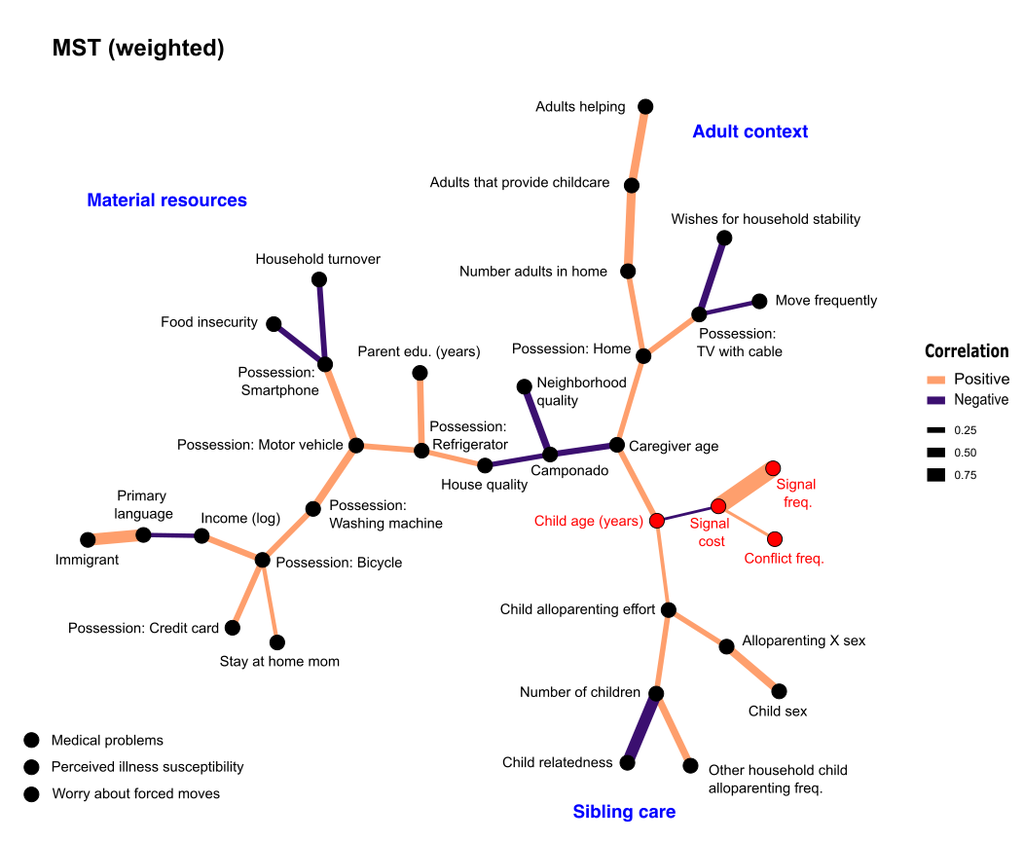

## 4.1 Distributions of signaling behavior, alloparenting effort, and conflict

Child sadness, crying, and temper tantrums were common and highly correlated with one another. See Figure 3 and Figure 4. Caregivers reported that 64 children (25%) were sad at least once a week, 102 children (39%) cried at least once a week, and 100 children (38%) threw temper tantrums at least once a week. A small subset of children engaged in these signals/states at least daily; sadness: 16 children (6.2%); crying: 31 children (12%); and tantrums: 42 children (16%). However, many children were reported to never engage in these signals/states; sadness: 78 children (30%); crying; 58 children (22%); and tantrums: 90 children (34%). For a visualization of how signal frequencies varied within children see Figure S1.

Conflict between children and caretakers was also common, with 92 children (35%) having conflicts with parents more than once a week. However, 109 children (42%) were described as never having conflicts with parents. See Figure 5. Conflict was also associated with higher signaling frequencies. See Figure 1 and Figure 4.

The frequency of child alloparenting effort, which previous research has linked to parent-child conflict, was bimodally distributed, with 137 children (56%) reported to never engage in it (36 instances were due to a child being an only child) and 78 children (32%) reported to help with childcare at least once a day. See Figure 6.

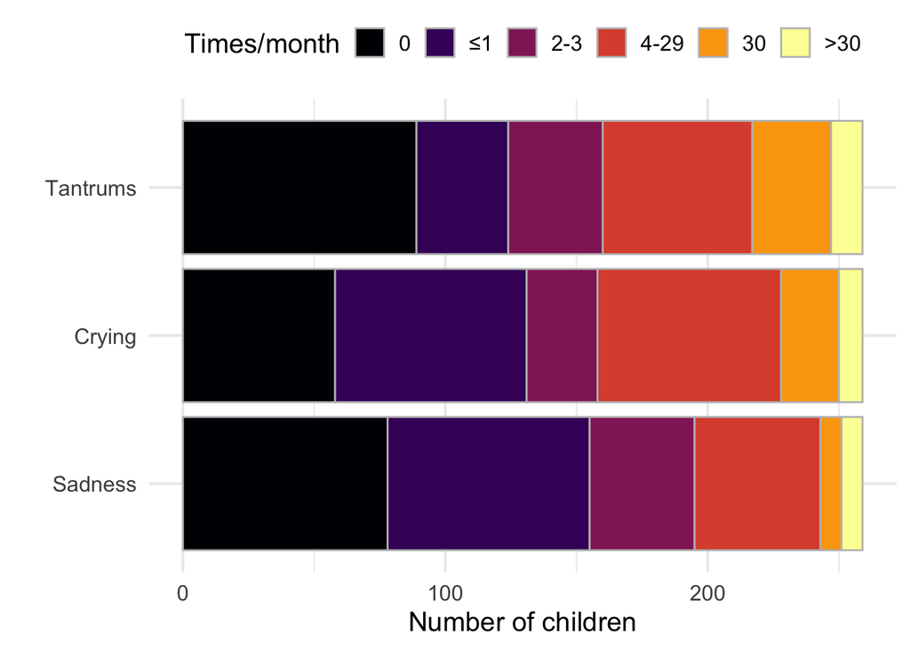

Figure 3: Frequencies of child sadness, crying, and temper tantrums per month as reported by the primary caretaker. Frequency key: 0 corresponds to “never,” <=1 corresponds to “once a month or less,” 2-3 corresponds to “more than once a month but less than once a week,” 4-29 corresponds to “more than once a week but not daily,” 30 corresponds to “daily,” and >30 corresponds to “multiple times per day.”

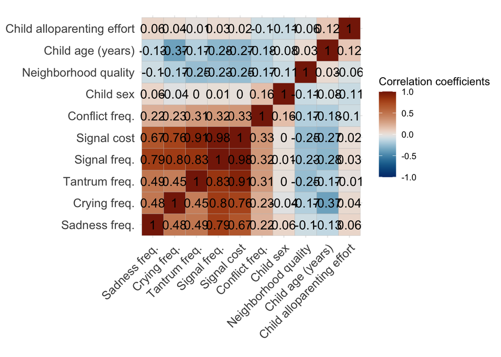

Figure 4: Correlation matrix of the frequencies of signals/states covered in the study with sex, child age, and the frequency of conflict between children and primary caretakers. For a more complete correlation matrix of study variables see Figure S2.

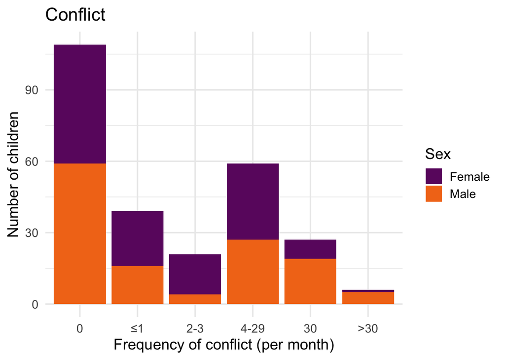

Figure 5: Frequency of conflict (per month) between child and primary caregiver as reported by primary caretaker. Color corresponds to sex of the child. Frequency key: 0 corresponds to “never,” <=1 corresponds to “once a month or less,” 2-3 corresponds to “more than once a month but less than once a week,” 4-29 corresponds to “more than once a week but not daily,” 30 corresponds to “daily,” and >30 corresponds to “multiple times per day.”

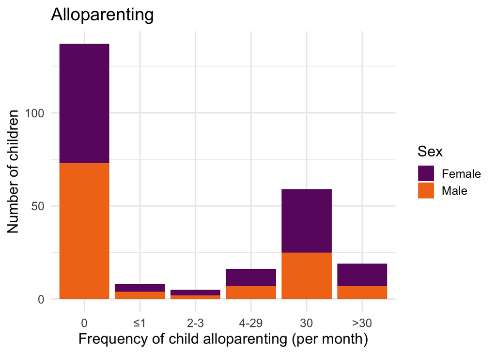

Figure 6: Frequency of a child’s alloparenting effort (per month) as reported by primary caretaker. Color corresponds to sex of the child. Frequency key: 0 corresponds to “never,” <=1 corresponds to “once a month or less,” 2-3 corresponds to “more than once a month but less than once a week,” 4-29 corresponds to “more than once a week but not daily,” 30 corresponds to “daily,” and >30 corresponds to “multiple times per day.”

## 4.2 Predictors of signaling frequency and conflict frequency

Using lasso regression, we explored all potential predictors of each child signal frequency, as well as of conflict frequency. See Figure 7.

[figure not shown]

Figure 7: Lasso regression models of each child signaling frequency and conflict frequency. Variables whose coefficient values were shrunk to 0 are not displayed. Models fit using quasi-Poisson regression.

The effects of particularly large risk or protective factors for child signaling are shown in Figure 8 and Figure 9.

[figure not shown]

Figure 8: Effects of selected predictors of child signaling frequencies when holding continuous variables at their mean and factor variables at their mode.

[figure not shown]

Figure 9: Effects of alloparenting frequency (per month) and signal cost and frequency of temper tantrums by sex.

The effects of particularly large risk or protective factors for conflict frequency are shown in Figure 10.

[figure not shown]

Figure 10: Effects of selected predictors of child-parent conflict frequencies when holding continuous variables at their mean and factor variables at their mode.

There were positive relationships between perceived relative neediness within the family and both child age and the frequency of child sadness. See Figure 11.

[figure not shown]

Figure 11: The proportion of children perceived by caretakers as being more needy, as needy, or less needy than a caretaker’s other children. A: Effect of child age on relative neediness B: Effect child sadness frequency on relative neediness. Outcome variable question wording: How much time, effort, and resources does this child need compared to your other children?

## 4.4 Relative need predicts relative investment

Signals are capable of eliciting better treatment because the information they provide alters the behavior of signal targets in ways that benefit the signaler. For this reason, we tested the association between caretaker perceptions of relative child need within the household and the caretaker’s relative investment within the household. Consistent with signaling theory, our model predicts a greater proportion of caretakers investing more in children who they deem needier and a greater proportion of caretakers investing less in children they deem less needy, controlling for the age of the child, and household demographics. See Figure 12.

[figure not shown]

Figure 12: The effect of perceived need (in terms of time, effort, and resources) relative investment within the household. Outcome variable question wording: How much time, effort, and resources do you put into this child compared to your other children?

## 4.5 Caregiver responses to most recent signal of need

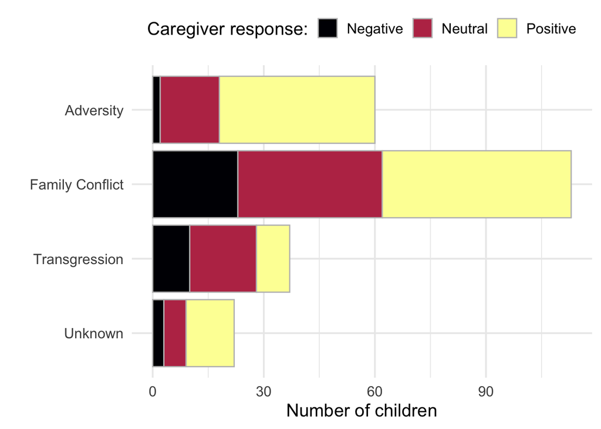

Figure 13: Frequencies of caregiver response to the last instance of child signaling by the cause of the signaling. Categories of causes were based on cluster analysis of more fine-grained cause variables. See Figure S3 for cluster dendrogram and Table S9 for the frequencies of causes and caregiver responses.

There were 6 instances in which a caregiver’s response involved acts which were both negative and positive from the child’s perspective. These were excluded from analyses due to their rarity.

[figure not shown]

Figure 14: Effects of selected predictors of the likelihood of positive, neutral, and negative responses to the last time a child became sad or cried when holding continuous variables at their mean and factor variables at their mode. 1 = evidence of the cause in the caregiver report; 0 = no evidence. The endpoints of the lines are dodged slightly for greater visibility. Dot size represents model predictions for each participant given their values of predictor variables. See Figure S4 for the effect of the cause involving punishment.

# 5 Discussion

Caregivers reported a wide range of child signaling frequencies. About half of children were reported to cry or throw tantrums more than once a month, and almost 40% were reported to do so more than once a week Figure 3. Frequencies of sadness, crying, and tantrums were positively correlated with each other and with the frequency of conflict with the primary caretaker Figure 4. They also loaded on PC1 in the same direction as indices of adversity, such as food insecurity, and in the opposite direction of indices of wealth and environmental quality, such as possessions, neighborhood quality, and income Figure 1.

Signaling decreased with child age, and increased with conflict with their primary caretaker, which were the two variables most closely linked with signaling in the MST Figure 2. In our lasso regression models (which excluded family conflict due to the likely bidirectional relationship between signaling and perceived conflict), child age and high neighborhood quality were consistently negatively associated with signaling frequency, as were household income, caregiver education, and number of adults helping with childcare. Medical problems were a consistent, albeit small positive predictor Figure 7, Figure 8.

Despite the differences in wealth, job certainty, discrimination, and living conditions between recent immigrants from the mainland and native Utilians (Davis 2014; Garcia, Gurven, and Blackwell 2017; Garcia 2018; Stonich 2000), primary language, immigration status, and residence in Camponado did not predict child signaling in our lasso regressions. These variables correlated with neighborhood quality, however, which was retained in our models, and lasso regression tends to retain only one of a set of correlated predictors (Zou and Hastie 2005).

The foregoing results are consistent with the hypothesis that sadness, crying, and tantrums are signals of need, and that children’s need is higher in adverse environments and at younger ages. One possible reason for the negative association of signaling with age, which is also seen in more industrialized settings (Zeifman 2013; Potegal and Davidson 2003; Koch 2003; Macfarlane, Allen, and Honzik 1962), is that as children mature, they are more capable of fulfilling their own needs, more able to ask others for what they need (Österman and Björkqvist 2010), and less vulnerable to threats. The effects of age on signaling are also likely due to how age influences the costliness of signaling need. For example, while the energetic cost of crying might be costly for the youngest children, it is likely insignificant for older children. Older children might instead need to weigh the reputational harm from crying against the potential increase in social support.

Consistent with signaling models that emphasize the role of conflicts of interest in favoring the use of costlier signals, caregiver perceptions of conflict and child signaling frequency were correlated Figure 4, and family conflict was the most common cause of a child’s recent signaling episode Figure 13. Although conflicts of interest do not always lead to overt behavioral conflict (Altmann 1980; Bateson 1994), it is likely many, if not most, conflicts are ultimately caused by conflicts of interest. Conflicts, in turn, were negatively associated with child age and higher neigborhood quality, and positively associated with male sex, medical problems, and (oddly) caregiver education Figure 10.

Caregiver responses to signals were generally positive or neutral, more so for situations involving injury and illness, and less so for situations involving family conflict, loss of privileges, and transgressions Figure 13, Figure 14. These patterns probably reflect a combination of confluences of interest vs. conflicts of interest between child and caretaker, some of which might represent caretaker investment in some children more than others, and less caretaker uncertainty about need in cases of injury and illness. That said, our model predicts positive responses in 35% of cases involving trangressions, suggesting that children are successful in negotiating better outcomes at least some of the time.

More frequent sadness was positively associated with perceived higher need relative to other children Figure 11. Although crying and tantrums were not associated with higher perceived need, this was likely due to their high correlation with sadness and the propensity of lasso regression to retain only one of a set of correlated predictors (Zou and Hastie 2005). Higher perceived need was associated with higher relative investment Figure 12. Signaling behavior did not predict differences in relative caregiver investment beyond its effect on perceived need Figure S6, similar to an experimental vignette study that found that the likelihood of costly support was largely mediated by the effect of costly signaling on belief in need (Gaffney et al. 2022). Altogether, the foregoing results generally support the hypothesis that the signals we investigated are costly, credible signals of need.

## 5.1 Limitations

The main limitation of this study is that it is completely exploratory: our data-driven analyses, which can reveal unexpected relationships and inspire new theory, also risk overfitting the data, suggesting associations that might not exist. Our study was also entirely cross-sectional, further limiting our ability to make causal inferences.

Our use of convenience and snowball sampling is also a limitation as it resulted in a non-probability sample which may not be representative of the broader population. This could happen if there was selection bias so that those who participated differed from the rest of the population in how they interacted with their children or how they assessed, remembered, and reported child behavior. All data come from caregiver reports, and therefore, reflect the biases of caretakers, whatever those might be.

# 6 Conclusion

Children face the challenge of eliciting support from others in times of adversity and opportunity. The signaling strategies of Utilian children were highly correlated and engaged in by children of all ages, albeit more frequently by younger children and those living in more adverse conditions, who plausibly had greater need. Consistent with signaling models that emphasize the role of conflicts of interest in favoring the use of costlier signals, child signaling effort was positively correlated with the frequency of conflict with caretakers and with perceptions of need, and greater perceptions of child need predicted greater investment in a given child. Our results suggest that evolutionary theories of signaling can help explain patterns of child sadness, crying, and temper tantrums.

# 7 Supplementary Information

## 7.1 Additional information for survey measures

| Variable | Survey question wording |
| --- | --- |
| Relative Need | How much time, effort, and resources does this child need compared to your other children? |
| Relative Investment | How much time, effort, and resources do you put into this child compared to your other children? |

Table S1: Variable names and question wording for measures about relative need and investment. Both questions had the following labels attached to each point on its Likert scale: Much less; Less; The same amount; More; Much more.

| Variable | Survey question wording |
| --- | --- |
| SchoolAges1 | My child has missed a lot of school due to illness. |
| SchoolAges2 | My child has had to deal with a variety of medical issues in their life so far. |

Table S2: Variable names and question wording for measures about a child’s health history. Both questions were asked using a Likert scale from 1-5 where 1 was labeled “Strongly disagree” and 5 was labeled “Strongly agree.”

| Variable | Survey question wording |
| --- | --- |
| IllnessAvoidance1 | If an illness is ‘going around’, my child will get it. |
| IllnessAvoidance2 | In general, my child is very susceptible to colds, flu, and other infectious diseases |
| IllnessAvoidance3 | My child’s immune system protects him/her from most illnesses that other kids get. |

Table S3: Variable names and question wording for measures about a child’s current likelihood of resisting illness. All three questions were asked using a Likert scale from 1-5 where 1 was labeled “Strongly disagree” and 5 was labeled “Strongly agree.” The scores for IllnessAvoidance1 and IllnessAvoidance2 were inverted so that 5 corresponded with the lowest susceptibility to illness, i.e., greatest *illness avoidance*.

| Variable | Survey question wording |
| --- | --- |
| FoodSecurity_1 | In the past year, the food that we bought often didn’t last, and we didn’t have money to get more. |
| FoodSecurity_2 | In the past year, we couldn’t afford to eat balanced meals. |
| FoodSecurity_3 | In the past year, I (or other adults in my household) sometimes cut the size of my meals or skipped meals because there wasn’t enough money for food. |
| FoodSecurity_4 | In the past year, I sometimes ate less than I felt I should because there wasn’t enough money for food. |
| FoodSecurity_5 | In the past year, I was sometimes hungry but didn’t eat because there wasn’t enough money for food. |
| FoodSecurity_6 | In the past year, I ate lower quality food because I couldn’t afford better food. |

Table S4: Variable names and question wording for the modified version of the USDA Food Security Questionnaire (Blumberg et al. 1999). All questions were asked using a Likert scale from 1-5 where 1 was labeled “Strongly disagree” and 5 was labeled “Strongly agree.”

| Variable | Survey question wording |
| --- | --- |
| HomeInstability_1 | We move our home a lot. |
| HomeInstability_2 | I wish our household felt more stable. |
| HomeInstability_3 | I worry that we will be forced to move before we are ready. |
| HomeInstability_4 | People move in and move out of our home frequently. |

Table S5: Variable names and question wording for the home instability questions. All questions were asked using a Likert scale from 1-5 where 1 was labeled “Disagree strongly” and 5 was labeled “Agree Strongly.”

| Variable | Survey question wording |
| --- | --- |
| NeighborhoodQuality_1 | As a place to live, my neighborhood is good quality. |
| NeighborhoodQuality_2 | As a place to raise children, my neighborhood is good quality. |
| NeighborhoodQuality_3 | My neighborhood quality has gotten worse over time. |
| NeighborhoodQuality_4 | My neighborhood is more dangerous than other parts of the island. |
| NeighborhoodQuality_5 | Sometimes I hear about a fight with a weapon in my neighborhood. |
| NeighborhoodQuality_6 | Sometimes I hear about illegal drug activity in my neighborhood. |
| NeighborhoodQuality_7 | Sometimes I hear about someone being badly hurt in my neighborhood. |
| NeighborhoodQuality_8 | Sometimes I hear about someone’s home being robbed in my neighborhood. |
| NeighborhoodQuality_9 | Sometimes I hear about someone being mugged in my neighborhood. |
| NeighborhoodQuality_10 | Sometimes I hear about someone being assaulted in my neighborhood. |

Table S6: Variable names and question wording for the perceptions of neighborhood quality questions. All questions were asked using a Likert scale from 1-5 where 1 was labeled “Strongly disagree” and 5 was labeled “Strongly agree.”

Positive: Give resources (e.g., toys, food, money)  
Positive: Promise resources  
Positive: Give attention/affection  
Positive: Promise attention/affection  
Positive: Give opportunities (e.g., loosen restrictions, new privileges, time with friends, fun activities)  
Positive: Promise opportunities  
Positive: Remove responsibilities (e.g., fewer chores)  
Positive: Promise removal of responsibilities  
Positive: Take child’s side in conflict (e.g., taking child’s side against sibling, intervening against bully)  
Positive: Give advice  
Positive: Other [Text Box]  
Neutral: Distract  
Neutral: Do nothing  
Neutral: Explain (e.g., go over why the child cannot have or do something)  
Neutral: Other [Text Box]  
Negative: Threaten removal of resources  
Negative: Remove resources (e.g., toys, food, money)  
Negative: Threaten withholding of attention/affection  
Negative: Withhold attention/affection (e.g., silent treatment, ignoring)  
Negative: Threaten loss of opportunities (e.g., freedom to move around the island, beach time, timeout, time with friends)  
Negative: Loss of opportunities  
Negative: Threaten more responsibilities (e.g., chores, alloparenting, homework)  
Negative: Add responsibilities  
Negative: Support adversary (e.g., taking sibling’s side)  
Negative: Threaten physical punishment  
Negative: Punish physically  
Negative: Punish verbally (includes yelling)  
Negative: Downplay adversity  
Negative: Other [Text Box]  
NA (Can’t remember, refuse to answer, etc)  
Other: Other [Text Box]

Table S7: List of options for research assistant to classify participant responses to the question of how they responded when their child was last sad or cried.

Motorized vehicle (scooter, 4-wheeler, etc.)  
Bicycle  
Television (TV) with cable  
Smartphone  
Washing machine  
Refrigerator  
A home that you own  
Credit card

Table S8: List of possessions owned (yes or no).

## 7.2 Figures

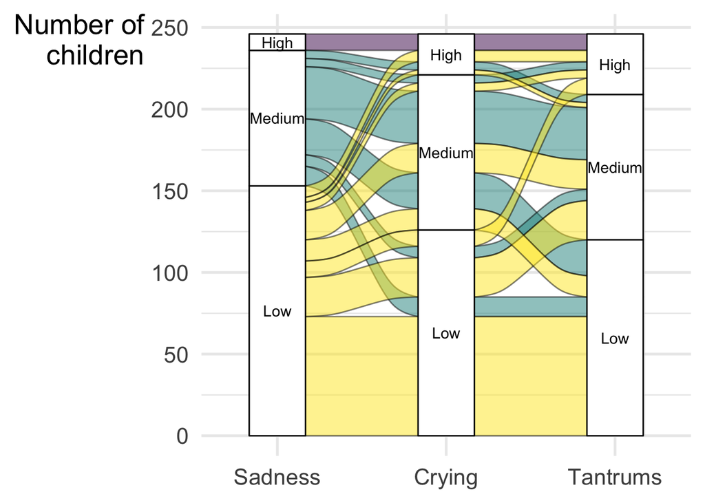

Figure S1: Combinations of signaling frequencies per month. Alluvium width equals the number of individuals with the same frequencies for the three signals/states. Stratum height equals the count of individuals at a given frequency. Frequency key: Low includes “never” and “once a month or less,” medium includes “more than once a month but less than once a week” and “more than once a week but not daily,” high includes “daily,” and “multiple times per day.”

[figure not shown]

Figure S2: Complete correlation matrix of study variables.

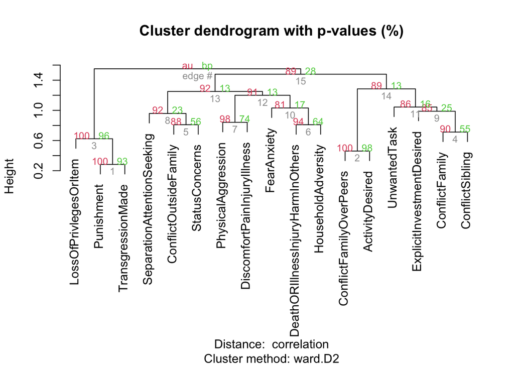

Figure S3: Cluster dendrogram for the causes of child signaling. Method = ward.D2.

[figure not shown]

Figure S4: The likelihood of positive, neutral, and negative responses to the last time a child became sad or cried when punishment was implicated in the cause when holding continuous variables at their mean and factor variables at their mode. 1 = evidence of the cause involving punishment. 0 = no evidence of the cause involving punishment. The endpoints of the lines are dodged slightly for greater visibility. Dot size represents model predictions for each participant given their values of predictor variables.

## 7.3 Tables

|  |  | N | % |
| --- | --- | --- | --- |
| ConflictFamily | No | 116 | 44.1 |
|  | Yes | 147 | 55.9 |
| ConflictFamilyOverPeers | No | 241 | 91.6 |
|  | Yes | 22 | 8.4 |
| ConflictSibling | No | 238 | 90.5 |
|  | Yes | 25 | 9.5 |
| ConflictOutsideFamily | No | 249 | 94.7 |
|  | Yes | 14 | 5.3 |
| DeathORIllnessInjuryHarmInOthers | No | 249 | 94.7 |
|  | Yes | 14 | 5.3 |
| HouseholdAdversity | No | 257 | 97.7 |
|  | Yes | 6 | 2.3 |
| ExplicitInvestmentDesired | No | 240 | 91.3 |
|  | Yes | 23 | 8.7 |
| ActivityDesired | No | 225 | 85.6 |
|  | Yes | 38 | 14.4 |
| UnwantedTask | No | 233 | 88.6 |
|  | Yes | 30 | 11.4 |
| Punishment | No | 236 | 89.7 |
|  | Yes | 27 | 10.3 |
| PhysicalAggression | No | 259 | 98.5 |
|  | Yes | 4 | 1.5 |
| LossOfPrivlegesOrItem | No | 243 | 92.4 |
|  | Yes | 20 | 7.6 |
| TransgressionMade | No | 231 | 87.8 |
|  | Yes | 32 | 12.2 |
| FearAnxiety | No | 256 | 97.3 |
|  | Yes | 7 | 2.7 |
| DiscomfortPainInjuryIllness | No | 235 | 89.4 |
|  | Yes | 28 | 10.6 |
| SeparationAttentionSeeking | No | 229 | 87.1 |
|  | Yes | 34 | 12.9 |
| StatusConcerns | No | 257 | 97.7 |
|  | Yes | 6 | 2.3 |

Table S9: Frequencies of various causes of the last time each child was sad or cried as reported by caretakers.

## 7.4 Coefficient plots

[figure not shown]

Figure S5: Effects of predictor variables on relative need between household children. Ordinal logistic regression model with elastic net penalties.

[figure not shown]

Figure S6: Effects of predictor variables on relative investment in household children. Ordinal logistic regression model with elastic net penalties.

[figure not shown]

Figure S7: Effects of predictor variables on caregiver responses to the last time a child was sad or cried. Ordinal logistic regression model with elastic net penalties.

# 8 Deleted sections

### 8.0.1 Child anthropometrics

We computed each child’s height, weight, and BMI Z-scores with respect to the CDC child growth standards (Kuczmarski et al. 2002).

For our independent variables of skinfold thickness, flexed bicep circumference, and grip strength on signaling behavior, we used the residuals from generalized additive models which modeled the effect of sex and age on each measurement using the mgcv package (Wood 2011). The resulting variables represent how each child differed from the average child for their given sex and age. We also centered and scaled the skinfold thickness residuals before summing them to create a body fat index.

### 8.0.2 Old discussion parts

The effect of age was smallest on child sadness. However, interpretation of this finding is more difficult due to the fact that, unlike crying and temper tantrums, sadness is thought to have important non-signaling functions including drawing one’s attention to a problem, motivating deeper analysis of one’s situation, and causing withdrawal from situations with low fitness prospects (Nesse 2019; Nettle 2009; Allen and Badcock 2003; Hagen 2011). By asking about sadness as a whole, our measure was unable to disentangle information caretakers gleaned from cues from information that came from signals.

## References

Albino, R. C., and V. J. Thompson. 1956. “The effects of sudden weaning on Zulu children.” *The British Journal of Medical Psychology* 29 (3-4): 177–210. https://doi.org/10.1111/j.2044-8341.1956.tb00914.x.

Allen, Nicholas B., and Paul B. T. Badcock. 2003. “The social risk hypothesis of depressed mood: evolutionary, psychosocial, and neurobiological perspectives.” *Psychological Bulletin* 129 (6): 887–913. https://doi.org/10.1037/0033-2909.129.6.887.

Altmann, Jeanne. 1980. *Baboon mothers and infants*. Cambridge, Mass: Harvard University Press.

André, Jean-Baptiste. 2010. “The Evolution of Reciprocity: Social Types or Social Incentives?” *The American Naturalist* 175 (2): 197–210. https://doi.org/10.1086/649597.

Andrews, Paul W., and J. Anderson Thomson. 2009. “The Bright Side of Being Blue: Depression as an Adaptation for Analyzing Complex Problems.” *Psychological Review* 116 (3): 620–54. https://doi.org/10.1037/a0016242.

Antón, Susan C, J. Josh Snodgrass, C. Crowder, A. Di Fiore, D. L. Duren, E. Fernadez-Duque, W. R. Leonard, et al. n.d. “Integrative Measurement Protocol for Morphological and Behavioral Research in Human Biology.” *American Journal of Physical Anthropology* 48 (2): 78–79.

Apicella, Coren L., Frank W. Marlowe, James H. Fowler, and Nicholas A. Christakis. 2012. “Social Networks and Cooperation in Hunter-Gatherers.” *Nature* 481 (7382): 497–501. https://doi.org/10.1038/nature10736.

Apicella, Coren L., and Joan B. Silk. 2019. “The Evolution of Human Cooperation.” *Current Biology* 29 (11): R447–50. https://doi.org/10.1016/j.cub.2019.03.036.

Balsters, Martijn J. H., Emiel J. Krahmer, Marc G. J. Swerts, and Ad J. J. M. Vingerhoets. 2013. “Emotional Tears Facilitate the Recognition of Sadness and the Perceived Need for Social Support.” *Evolutionary Psychology* 11 (1): 148–58. https://doi.org/10.1177/147470491301100114.

Bani Salameh, Ayman. K., Malakeh. Z. Malak, Rasmieh. M. Al-Amer, Omar. S. H. Al Omari, Mamdouh El-Hneiti, and Loai. M. Abu Sharour. 2021. “Assessment of Temper Tantrums Behaviour Among Preschool Children in Jordan.” *Journal of Pediatric Nursing* 59 (July): e106–11. https://doi.org/10.1016/j.pedn.2021.02.008.

Barbarin, Oscar A. 1999. “Social Risks and Psychological Adjustment: A Comparison of African American and South African Children.” *Child Development* 70 (6): 1348–59.

Barnett, Melissa A., Lilly Shanahan, Min Deng, Mary E. Haskett, and Martha J. Cox. 2010. “Independent and Interactive Contributions of Parenting Behaviors and Beliefs in the Prediction of Early Childhood Behavior Problems.” *Parenting* 10 (1): 43–59. https://doi.org/10.1080/15295190903014604.

Barr, R. G. 1990. “The early crying paradox : A modest proposal.” *Human Nature (Hawthorne, N.Y.)* 1 (4): 355–89. https://doi.org/10.1007/BF02734051.

Barr, R. G., M. Konner, R. Bakeman, and L. Adamson. 1991. “Crying in !Kung San infants: a test of the cultural specificity hypothesis.” *Developmental Medicine and Child Neurology* 33 (7): 601–10. https://doi.org/10.1111/j.1469-8749.1991.tb14930.x.

Barry, Herbert, and Leonora M. Paxson. 1971. “Infancy and Early Childhood: Cross-Cultural Codes 2.” *Ethnology* 10 (4): 466–508. https://doi.org/10.2307/3773177.

Bateson, Patrick. 1994. “The Dynamics of Parent-Offspring Relationships in Mammals.” *Trends in Ecology & Evolution* 9 (10): 399–403. https://doi.org/10.1016/0169-5347(94)90066-3.

Beaulieu, David A., and Daphne Bugental. 2008. “Contingent Parental Investment: An Evolutionary Framework for Understanding Early Interaction Between Mothers and Children.” *Evolution and Human Behavior* 29 (4): 249–55. https://doi.org/10.1016/j.evolhumbehav.2008.01.002.

Belden, Andy C., Nicole Renick Thomson, and Joan L. Luby. 2008. “Temper Tantrums in Healthy Versus Depressed and Disruptive Preschoolers: Defining Tantrum Behaviors Associated with Clinical Problems.” *The Journal of Pediatrics* 152 (1): 117–22. https://doi.org/10.1016/j.jpeds.2007.06.030.

Bergstrom, Carl T, and Theodore C Bergstrom. 1999. “Does Mother Nature Punish Rotten Kids?” *Journal of Bioeconomics* 1: 47–72.

Bhatia, Manjeet S, Naresh K Dhar, Puneet K Singhal, Vibha R Nigam, Satish C Malik, and DN Mullick. 1990. “Temper Tantrums: Prevalence and Etiology in a Non-Referral Outpatient Setting.” *Clinical Pediatrics* 29 (6): 311–15.

Blumberg, S J, K Bialostosky, W L Hamilton, and R R Briefel. 1999. “The Effectiveness of a Short Form of the Household Food Security Scale.” *American Journal of Public Health* 89 (8): 1231–34. https://doi.org/10.2105/AJPH.89.8.1231.

Blurton Jones, Nicholas G. 1993. “The Lives of Hunter-Gatherer Children: Effects of Parental Behavior and Parental Reproductive Strategy.” In, edited by Michael E. Pereira and Lynn A. Fairbanks. Chicago; London: The University of Chicago Press.

Bogart, Kathleen R., and David Matsumoto. 2010. “Living with Moebius syndrome: adjustment, social competence, and satisfaction with life.” *The Cleft Palate-Craniofacial Journal: Official Publication of the American Cleft Palate-Craniofacial Association* 47 (2): 134–42. https://doi.org/10.1597/08-257_1.

Bogart, Kathleen R., Linda Tickle-Degnen, and Matthew S. Joffe. 2012. “Social interaction experiences of adults with Moebius Syndrome: a focus group.” *Journal of Health Psychology* 17 (8): 1212–22. https://doi.org/10.1177/1359105311432491.

Bossan, Benjamin, Peter Hammerstein, and Arnulf Koehncke. 2013. “We Were All Young Once: An Intragenomic Perspective on Parentoffspring Conflict.” *Proceedings of the Royal Society B: Biological Sciences* 280 (1754): 1–7. https://doi.org/10.1098/rspb.2012.2637.

Bowlby, John. 1980. *Attachment and Loss*. Attachment and Loss. New York, NY, US: Basic Books.

Burchinal, Margaret, Debra Skinner, and J. Steven Reznick. 2010. “European American and African American Mothers’ Beliefs about Parenting and Disciplining Infants: A Mixed-Method Analysis.” *Parenting* 10 (2): 79–96. https://doi.org/10.1080/15295190903212604.

Burrows, Edwin G. (Edwin Grant), and Melford E. Spiro. 1953. *An atoll culture: ethnography of Ifaluk in the central Carolines*. Behavior science monographs. https://ehrafworldcultures.yale.edu/cultures/or21/documents/042.

Caro, Shana M., Ashleigh S. Griffin, Camilla A. Hinde, and Stuart A. West. 2016. “Unpredictable Environments Lead to the Evolution of Parental Neglect in Birds.” *Nature Communications* 7 (1): 10985. https://doi.org/10.1038/ncomms10985.

Caro, Shana M., Stuart A. West, and Ashleigh S. Griffin. 2016. “Sibling Conflict and Dishonest Signaling in Birds.” *Proceedings of the National Academy of Sciences* 113 (48): 13803–8. https://doi.org/10.1073/pnas.1606378113.

Chaudhary, Nikhil, Gul Deniz Salali, and Annie Swanepoel. 2024. “Sensitive Responsiveness and Multiple Caregiving Networks Among Mbendjele BaYaka Hunter-Gatherers: Potential Implications for Psychological Development and Well-Being.” *Developmental Psychology* 60 (3): 422–40. https://doi.org/10.1037/dev0001601.

Chisausky, Jacob, Carl Bergstrom, Kevin Zollman, and Graeme Ruxton. 2023. “Honest Signalling Made Simple.”

Clutton-Brock, T. H. 1991. “The evolution of parental care.”

Cornelius, Randolph R., and Susan M. Labott. 2001. “The Social Psychological Aspects of Crying.” In. Routledge.

Cretser, Gary, William Lombardo, Barbara Lombardo, and Sharon Mathis. 1982. “Reactions to Men and Women Who Cry: A Study of Sex Differences in Perceived Societal Attitudes Versus Personal Attitudes.” *Perceptual and Motor Skills* 55 (2): 479–86. https://doi.org/10.2466/pms.1982.55.2.479.

Daly, Martin. 1990. “Evolutionary Theory and Parental Motives.” In, edited by A. Krasnegor and R. S. Bridges. Oxford University Press.

Daly, Martin, and Margo Wilson. 1983. *Sex, Evolution, and Behavior*. Belmont: Wadsworth Publishing Company.

———. 1984. “A Sociobiological Analysis of Human Infanticide.” In, edited by Glenn Hausfater and Sarah Blaffer Hrdy, 487–502. New York: Aldine Press.

———. 1987. “The Darwinian psychology of discriminative parental solicitude.” *Nebraska Symposium on Motivation. Nebraska Symposium on Motivation* 35: 91–144.

Daniels, Elizabeth, Barbara Mandleco, and Karlen E. Luthy. 2012. “Assessment, Management, and Prevention of Childhood Temper Tantrums.” *Journal of the American Association of Nurse Practitioners* 24 (10): 569. https://doi.org/10.1111/j.1745-7599.2012.00755.x.

Darwin, Charles. 1872. *The Expression of the Emotions in Man and Animals*. London: John Murray.

Davis, Brittany Y. 2014. “Angling for Inclusion: Marine Conservation, Livelihoods,Local Knowledge, and Tourism on Utila, Honduras.” PhD thesis.

Davison, Raziel J., and Michael Gurven. 2022. “The Importance of Elders: Extending Hamilton’s Force of Selection to Include Intergenerational Transfers.” *Proceedings of the National Academy of Sciences* 119 (28): e2200073119.

Davison, Raziel J., and Michael D Gurven. 2021. “Human Uniqueness? Life History Diversity Among Small-Scale Societies and Chimpanzees.” *PLoS One* 16 (2): e0239170.

Dawkins, Richard. 1976. *The Selfish Gene*. New York: Oxford University Press.

Dennis, Wayne. 1940. “The Hopi Child.”

Du Bois, Cora Alice, Abram Kardiner, and Emil Oberholzer. n.d. *The people of Alor: a social-psychological study of an East Indian Island*. Minneapolis: Univ. of Minnesota Press. https://ehrafworldcultures.yale.edu/cultures/of05/documents/001.

Emanuel, Aviv, and Eran Eldar. 2023. “Emotions as Computations.” *Neuroscience & Biobehavioral Reviews* 144 (January): 104977. https://doi.org/10.1016/j.neubiorev.2022.104977.

Emlen, Stephen T. 1995. “An Evolutionary Theory of the Family.” *Proceedings of the National Academy of Sciences* 92 (18): 8092–99. https://doi.org/10.1073/pnas.92.18.8092.

Emlen, Stephen T., and Peter H Wrege. 1992. “Parentoffspring Conflict and the Recruitment of Helpers Among Bee-Eaters.” *Nature* 356 (6367): 331–33. https://doi.org/10.1038/356331a0.

Eshel, Ilan, and Marcus W Feldman. 1991. “The Handicap Principle in Parent-Offspring Conflict: Comparison of Optimality and Population-Genetic Analyses.” *The American Naturalist* 137 (2): 167–85.

Flinn, M. 1989. “Household Composition and Female Reproductive Strategies in a Trinidadian Village.” In, edited by Anne Rasa, Christian Vogel, and Eckert Voland. London ; New York: Chapman; Hall. https://searchit.libraries.wsu.edu/discovery/fulldisplay?vid=01ALLIANCE_WSU:WSU&id=99177033160001451&inst=01ALLIANCE_NETWORK&context=L.

Fouts, Hillary N., Barry S. Hewlett, and Michael E. Lamb. 2005. “Parent-Offspring Weaning Conflicts Among the Bofi Farmers and Foragers of Central Africa.” *Current Anthropology* 46 (1): 29–50. https://doi.org/10.1086/425659.

Frankenhuis, Willem E., and Dorsa Amir. 2022. “What Is the Expected Human Childhood? Insights from Evolutionary Anthropology.” *Development and Psychopathology* 34 (2): 473–97. https://doi.org/10.1017/S0954579421001401.

Friedman, Jerome H., Trevor Hastie, and Rob Tibshirani. 2010. “Regularization Paths for Generalized Linear Models via Coordinate Descent.” *Journal of Statistical Software* 33 (February): 1–22. https://doi.org/10.18637/jss.v033.i01.

Frodi, Ann. 1985. “When Empathy Fails.” In, edited by Barry M. Lester and C. F. Zachariah Boukydis, 263–77. Boston, MA: Springer US. https://doi.org/10.1007/978-1-4613-2381-5_12.

Fujiwara, Takeo, Ronald G. Barr, Rollin Brant, and Marilyn Barr. 2011. “Infant Distress at Five Weeks of Age and Caregiver Frustration.” *The Journal of Pediatrics* 159 (3): 425–430.e2. https://doi.org/10.1016/j.jpeds.2011.02.010.

Furlow, F. Bryant. 1997. “Human Neonatal Cry Quality as an Honest Signal of Fitness.” *Evolution and Human Behavior* 18 (3): 175–93. https://doi.org/10.1016/S1090-5138(97)00006-8.

Gaffney, Michael R., Kai H. Adams, Kristen L. Syme, and Edward H. Hagen. 2022. “Depression and Suicidality as Evolved Credible Signals of Need in Social Conflicts.” *Evolution and Human Behavior* 43 (3): 242–56. https://doi.org/10.1016/j.evolhumbehav.2022.02.004.

Garcia, Angela R. 2018. “The Embodiment of Stress: Do Cortisol-Immune Interactions Moderate Social Influences on Health?” PhD thesis. https://escholarship.org/uc/item/40j006mc.

Garcia, Angela R., Michael Gurven, and Aaron D. Blackwell. 2017. “A Matter of Perception: Perceived Socio-Economic Status and Cortisol on the Island of Utila, Honduras.” *American Journal of Human Biology* 29 (5): 1–17. https://doi.org/https://doi.org/10.1002/ajhb.23031.

Gibson, M. A., and E. Gurmu. 2011. “Land Inheritance Establishes Sibling Competition for Marriage and Reproduction in Rural Ethiopia.” *Proceedings of the National Academy of Sciences* 108 (6): 2200–2204. https://doi.org/10.1073/pnas.1010241108.

Godfray, H. C. J. 1991. “Signalling of Need by Offspring to Their Parents.” *Nature* 352 (6333): 328–30. https://doi.org/10.1038/352328a0.

———. 1995. “Evolutionary Theory of Parentoffspring Conflict.” *Nature* 376 (6536): 133–38. https://doi.org/10.1038/376133a0.

Godfray, H. C. J., and R. A. Johnstone. 2000. “Begging and Bleating: The Evolution of Parent-Offspring Signalling.” *Philosophical Transactions of the Royal Society B: Biological Sciences* 355 (1403): 1581–91. https://doi.org/10.1098/rstb.2000.0719.

Godfray, H. C. J., and G. A. Parker. 1992. “Sibling Competition, Parent-Offspring Conflict and Clutch Size.” *Animal Behaviour* 43 (3): 473–90. https://doi.org/10.1016/S0003-3472(05)80106-X.

Goodall, Jane. 1986. *The Chimpanzees of Gombe*. Cambridge, Mass.: Belknap Press of Harvard University Press.

Goodenough, Florence Laura. 1931. “Anger in Young Children.” PhD thesis, THE UNIVERSITY OF MINNESOTA PRESS MINNEAPOLIS.

Gracanin, Asmir, Lauren M. Bylsma, and Ad J. J. M. Vingerhoets. 2018. “Why Only Humans Shed Emotional Tears.” *Human Nature-an Interdisciplinary Biosocial Perspective* 29 (2): 104–33. https://doi.org/10.1007/s12110-018-9312-8.

Guilford, Tim, and Marian Stamp Dawkins. 1995. “What Are Conventional Signals?” *Animal Behaviour* 49 (6): 1689–95. https://doi.org/10.1016/0003-3472(95)90090-X.

Gunderson, Christopher A., Alysha Baker, Alona D. Pence, and Leanne Ten Brinke. 2021. “Interpersonal Consequences of Deceptive Expressions of Sadness.” *Personality and Social Psychology Bulletin* 49 (1): 97–109. https://doi.org/10.1177/01461672211059700.

Gurven, Michael, Wesley Allen-Arave, Kim Hill, and Magdalena Hurtado. 2000. ““It’s a Wonderful Life”: Signaling Generosity Among the Ache of Paraguay.” *Evolution and Human Behavior*, 20.

Hadley, Craig, Tefera Belachew, David Lindstrom, and Fasil Tessema. 2011. “The Shape of Things to Come? Household Dependency Ratio and Adolescent Nutritional Status in Rural and Urban Ethiopia.” *American Journal of Physical Anthropology* 144 (4): 643–52. https://doi.org/10.1002/ajpa.21463.

Hagen, Edward H. 1999. “The Functions of Postpartum Depression.” *Evolution and Human Behavior* 20 (5): 325–59. https://doi.org/10.1016/S1090-5138(99)00016-1.

———. 2011. “Evolutionary Theories of Depression: A Critical Review.” *The Canadian Journal of Psychiatry* 56 (12): 716–26. https://doi.org/10.1177/070674371105601203.

Hagen, Edward H., and H. Clark Barrett. 2009. “Cooperative Breeding and Adolescent Siblings: Evidence for the Ecological Constraints Model?” *Current Anthropology* 50 (5): 727–37. https://doi.org/10.1086/605328.

Hagen, Edward H., H. Clark Barrett, and Michael E. Price. 2006. “Do Human Parents Face a Quantity-Quality Tradeoff?: Evidence from a Shuar Community.” *American Journal of Physical Anthropology* 130 (3): 405–18. https://doi.org/10.1002/ajpa.20272.

Hagen, Edward H., Paul J. Watson, and Peter Hammerstein. 2008. “Gestures of Despair and Hope: A View on Deliberate Self-Harm From Economics and Evolutionary Biology.” *Biological Theory* 3 (2): 123–38. https://doi.org/10.1162/biot.2008.3.2.123.

Hamilton, W. D. 1964. “The Genetical Evolution of Social Behaviour. i.” *Journal of Theoretical Biology* 7 (1): 1–16. https://doi.org/10.1016/0022-5193(64)90038-4.

Hasson, Oren. 2009. “Emotional Tears as Biological Signals.” *Evolutionary Psychology* 7 (3): 363–70.

Helfrecht, Courtney, and Courtney L. Meehan. 2016. “Sibling Effects on Nutritional Status: Intersections of Cooperation and Competition Across Development.” *American Journal of Human Biology* 28 (2): 159–70. https://doi.org/10.1002/ajhb.22763.

Henderson, Richard N. 1966. *An outline of traditional Onitsha Ibo socialization*. Ibadan: Institute of Education, University of Ibadan.

Hendriks, Michelle C. P., and Ad J. J. M. Vingerhoets. 2006. “Social Messages of Crying Faces: Their Influence on Anticipated Person Perception, Emotions and Behavioural Responses.” *Cognition & Emotion* 20 (6): 878–86. https://doi.org/10.1080/02699930500450218.

Hewlett, B. S., M. E. Lamb, D. Shannon, B. Leyendecker, and A. Schölmerich. 1998. “Culture and early infancy among central African foragers and farmers.” *Developmental Psychology* 34 (4): 653–61. https://doi.org/10.1037//0012-1649.34.4.653.

Hilger, M. Inez. 1957. *Araucanian Child Life And Its Cultural Background*. Washington: Smithsonian. http://ehrafworldcultures.yale.edu/document?id=sg04-010.

Hill, Kim R., Robert S. Walker, Miran Božičević, James Eder, Thomas Headland, Barry Hewlett, A. Magdalena Hurtado, Frank Marlowe, Polly Wiessner, and Brian Wood. 2011. “Co-Residence Patterns in Hunter-Gatherer Societies Show Unique Human Social Structure.” *Science* 331 (6022): 1286–89. https://doi.org/10.1126/science.1199071.

Horwitz, Allan V., Jerome C. Wakefield, and Lorenzo Lorenzo-Luaces. 2017. “History of Depression.” https://www.oxfordhandbooks.com/view/10.1093/oxfordhb/9780199973965.001.0001/oxfordhb-9780199973965-e-2.

Howard, Cynthia R., Nancy Lanphear, Bruce P. Lanphear, Shirley Eberly, and Ruth A. Lawrence. 2006. “Parental Responses to Infant Crying and Colic: The Effect on Breastfeeding Duration.” *Breastfeeding Medicine* 1 (3): 146–55. https://doi.org/10.1089/bfm.2006.1.146.

Hrdy, Sarah Blaffer. 2009. *Mothers and others: the evolutionary origins of mutual understanding*. Cambridge, Mass.: Belknap Press of Harvard University Press.

Huth, Karoline BS, Jill de Ron, Anneke E Goudriaan, Judy Luigjes, Reza Mohammadi, Ruth J van Holst, Eric-Jan Wagenmakers, and Maarten Marsman. 2023. “Bayesian Analysis of Cross-Sectional Networks: A Tutorial in R and JASP.” *Advances in Methods and Practices in Psychological Science* 6 (4): 25152459231193334.

Jesser, J. C. 1989. “Men and Crying.” *Changing Men*, no. 20: 12–15.

Johnson, Allen. 2003. *Families of the Forest: The Matsigenka Indians of the Peruvian Amazon*. Univ of California Press.

Kaplan, Hillard S., and Heather Dove. 1987. “Infant Development Among the Ache of Eastern Paraguay.” *Developmental Psychology* 23 (2): 190–98. https://doi.org/10.1037/0012-1649.23.2.190.

Kaplan, Hillard S., Paul L. Hooper, and Michael Gurven. 2009. “The Evolutionary and Ecological Roots of Human Social Organization.” *Philosophical Transactions of the Royal Society B: Biological Sciences* 364 (1533): 3289–99. https://doi.org/10.1098/rstb.2009.0115.

Kennedy, Patrick, and Andrew N Radford. 2021. “Kin Blackmail as a Coercive Route to Altruism.” *The American Naturalist* 197 (2): 266–73.

Koch, Ehud. 2003. “Reflections on a Study of Temper Tantrums in Older Children.” *Psychoanalytic Psychology* 20 (3): 456–71. https://doi.org/10.1037/0736-9735.20.3.456.

Konner, Melvin. 1972. *Aspects of the developmental ecology of a foraging people*. At the University Press. https://ehrafworldcultures.yale.edu/cultures/fx10/documents/033.

———. 1974. “Ethological Studies of Child Behavior.” In, edited by N. Blurton Jones, Revised ed. edition, 285–304. Cambridge: Cambridge University Press.

Kramer, Karen L. 2018. “The Cooperative Economy of Food: Implications for Human Life History and Physiology.” *Physiology & Behavior*, The pace of life and feeding: Health implications, 193 (September): 196–204. https://doi.org/10.1016/j.physbeh.2018.03.029.

Kramer, Karen L., and Amanda Veile. 2018. “Infant allocare in traditional societies.” *Physiology & Behavior* 193 (Pt A): 117–26. https://doi.org/10.1016/j.physbeh.2018.02.054.

Kruger, Ann Cale, and Melvin Konner. 2010. “Who Responds to Crying?” *Human Nature* 21 (3): 309–29. https://doi.org/10.1007/s12110-010-9095-z.

Kuczmarski, Robert J., Cynthia L. Ogden, Shumei S. Guo, Laurence M. Grummer-Strawn, Katherine M. Flegal, Zuguo Mei, Rong Wei, Lester R. Curtin, Alex F. Roche, and Clifford L. Johnson. 2002. “2000 CDC Growth Charts for the United States: methods and development.” *Vital and Health Statistics. Series 11, Data from the National Health Survey*, no. 246 (May): 1–190.

Kurth, Elisabeth, Holly Powell Kennedy, Elisabeth Spichiger, Irene Hösli, and Elisabeth Zemp Stutz. 2011. “Crying Babies, Tired Mothers: What Do We Know? A Systematic Review.” *Midwifery* 27 (2): 187–94. https://doi.org/10.1016/j.midw.2009.05.012.

Kushnick, Geoff. 2006. “Parent-Offspring Conflict Among the Karo of North Sumatra.” PhD thesis.

———. 2023. “Marriage: Parent-Offspring Conflict.” In, edited by Todd K. Shackelford, 1–5. Cham: Springer International Publishing. https://doi.org/10.1007/978-3-031-08956-5_1416-1.

Lawson, David W., Alexandra Alvergne, and Mhairi A. Gibson. 2012. “The Life-History Trade-Off Between Fertility and Child Survival.” *Proceedings of the Royal Society B: Biological Sciences* 279 (1748): 4755–64. https://doi.org/10.1098/rspb.2012.1635.

Lawson, David W., and Monique Borgerhoff Mulder. 2016. “The Offspring Quantity–Quality Trade-Off and Human Fertility Variation.” *Philosophical Transactions of the Royal Society B: Biological Sciences* 371 (1692): 20150145.

Lawson, David W., and R. Mace. 2008. “Sibling Configuration and Childhood Growth in Contemporary British Families.” *International Journal of Epidemiology* 37 (6): 1408–21. https://doi.org/10.1093/ije/dyn116.

Levenson, Robert W. 1999. “The Intrapersonal Functions of Emotion.” *Cognition and Emotion* 13 (5): 481–504. https://doi.org/10.1080/026999399379159.

Lin, Hung-Chu, and Robert McFatter. 2012. “Empathy and Distress: Two Distinct but Related Emotions in Response to Infant Crying.” *Infant Behavior and Development* 35 (4): 887–97. https://doi.org/10.1016/j.infbeh.2012.08.001.

Lohman, Timothy G., Alex F. Roche, and Reynaldo Martorell. 1988. *Anthropometric standardization reference manual*. Champaign, IL: Human Kinetics Books.

Lowe, Edward D. 2003. “Identity, Activity, and the Well-Being of Adolescents and Youths: Lessons from Young People in a Micronesian Society.” *Culture, Medicine and Psychiatry* 27 (2): 187–219. https://doi.org/10.1023/A:1024274024956.

Lummaa, V. 1998. “Why Cry? Adaptive Significance of Intensive Crying in Human Infants.” *Evolution and Human Behavior* 19 (3): 193–202. https://doi.org/10.1016/S1090-5138(98)00014-2.

Mace, Ruth. 1996. “Biased Parental Investment and Reproductive Success in Gabbra Pastoralists.” *Behavioral Ecology and Sociobiology* 38 (2): 75–81. https://doi.org/10.1007/s002650050219.

Macfarlane, Jean Walker, Lucile Allen, and Marjorie P. Honzik. 1962. *A Developmental Study of the Behavior Problems of Normal Children Between 21 Months and 14 Years*. Univ of California Press.

Maute, Monique, and Sonja Perren. 2018. “Ignoring Children’s Bedtime Crying: The Power of Western-Oriented Beliefs.” *Infant Mental Health Journal* 39 (2): 220–30. https://doi.org/10.1002/imhj.21700.

Maynard Smith, J., and D. G. C. Harper. 1995. “Animal Signals: Models and Terminology.” *Journal of Theoretical Biology* 177 (3): 305–11. https://doi.org/10.1006/jtbi.1995.0248.

Maynard-Smith, John, and David Harper. 2004. *Animal Signals*. 1st edition. New York: Oxford University Press.

Meehan, Courtney L. 2009. “Maternal Time Allocation in Two Cooperative Childrearing Societies.” *Human Nature* 20 (4): 375–93. https://doi.org/10.1007/s12110-009-9076-2.

Meehan, Courtney L., Edward H. Hagen, and Barry S. Hewlett. 2017. “Persistence of Infant Care Patterns Among Aka Foragers.” In, edited by Victoria Reyes-García and Aili Pyhälä, 213–31. Switzerland: Springer International Publishing. https://doi.org/10.1007/978-3-319-42271-8_12.

Mehr, Samuel A., Max M. Krasnow, Gregory A. Bryant, and Edward H. Hagen. 2021. “Origins of Music in Credible Signaling.” *Behavioral and Brain Sciences* 44 (January): e60. https://doi.org/10.1017/S0140525X20000345.

Meij, J. J., D. Van Bodegom, J. B. Ziem, J. Amankwa, A. M. Polderman, T. B. L. Kirkwood, A. J. M. De Craen, B. J. Zwaan, and R. G. J. Westendorp. 2009. “Quality-Quantity Trade-Off of Human Offspring Under Adverse Environmental Conditions.” *Journal of Evolutionary Biology* 22 (5): 1014–23. https://doi.org/10.1111/j.1420-9101.2009.01713.x.

Mock, Douglas W., Matthew B. Dugas, and Stephanie A. Strickler. 2011. “Honest Begging: Expanding from Signal of Need.” *Behavioral Ecology* 22 (5): 909–17. https://doi.org/10.1093/beheco/arr091.

Mock, Douglas W., and Geoffrey A. Parker. 1997. *The Evolution of Sibling Rivalry*. Oxford Series in Ecology and Evolution. Oxford, New York: Oxford University Press.

Müller, Fernanda. 2021. “*I Cry, Therefore I Am*: An Anthropological Study of Babies’ Interactions.” *Learning, Culture and Social Interaction* 31 (December): 100562. https://doi.org/10.1016/j.lcsi.2021.100562.

Murube, Juan. 2009. “Basal, reflex, and psycho-emotional tears.” *The Ocular Surface* 7 (2): 60–66. https://doi.org/10.1016/s1542-0124(12)70296-3.

Myers, Fred R. 1988. “The Logic and Meaning of Anger Among Pintupi Aborigines.” *Man*, 589–610.

Nesse, Randolph M. 1990. “Evolutionary Explanations of Emotions.” *Human Nature* 1 (3): 261–89. https://doi.org/10.1007/BF02733986.

———. 2019. *Good Reasons for Bad Feelings: Insights from the Frontier of Evolutionary Psychiatry*. Penguin.

Nesse, Randolph M., and Phoebe C. Ellsworth. 2009. “Evolution, emotions, and emotional disorders.” *The American Psychologist* 64 (2): 129–39. https://doi.org/10.1037/a0013503.

Nettle, Daniel. 2009. “An Evolutionary Model of Low Mood States.” *Journal of Theoretical Biology* 257 (1): 100–103. https://doi.org/10.1016/j.jtbi.2008.10.033.

Österman, Karin, and Kaj Björkqvist. 2010. “A Cross-Sectional Study of Onset, Cessation, Frequency, and Duration of Children’s Temper Tantrums in a Nonclinical Sample.” *Psychological Reports* 106 (2): 448–54.

Potegal, Michael. 2019. “On Being, Mad, Sad, and Very Young.” In, edited by Amy Krain Roy, Melissa A. Brotman, and Ellen Leibenluft. New York, N.Y.: Oxford University Press.

Potegal, Michael, and Richard J. Davidson. 2003. “Temper Tantrums in Young Children: 1. Behavioral Composition:” *Journal of Developmental & Behavioral Pediatrics* 24 (3): 140–47. https://doi.org/10.1097/00004703-200306000-00002.

Preuschoft, Signe, and Carel van Schaik. 2000. “Dominance and Communication: Conflict Management in Various Social Settings.” In, edited by Filippo Aurelli and Franz de wall, 77–105. University of California Press.

Rao, Madu, Elliott M Blass, Marie M Brignol, Lauren Marino, and Leonard Glass. 1997. “Reduced Heat Loss Following Sucrose Ingestion in Premature and Normal Human Newborns.” *Early Human Development* 48 (1): 109–16. https://doi.org/10.1016/S0378-3782(96)01847-6.

Reed, Lawrence Ian, and Peter DeScioli. 2017. “The Communicative Function of Sad Facial Expressions.” *Evolutionary Psychology* 15 (1): 147470491770041. https://doi.org/10.1177/1474704917700418.

Reijneveld, Sijmen A., Marcel F. van der Wal, Emily Brugman, Remy A. Hira Sing, and S. Pauline Verloove-Vanhorick. 2004. “Infant Crying and Abuse.” *The Lancet* 364 (9442): 1340–42. https://doi.org/10.1016/S0140-6736(04)17191-2.

Rosenberg, Karen R. 2021. “The Evolution of Human Infancy: Why It Helps to Be Helpless.” *Annual Review of Anthropology* 50 (Volume 50, 2021): 423–40. https://doi.org/10.1146/annurev-anthro-111819-105454.

Salmon, Catherine A, and Jessica A Hehman. 2014. “The Evolutionary Psychology of Sibling Conflict and Siblicide.” In, edited by Todd K Shackleford and Ronald D Hansen. Evolutionary Psychology. New York: Springer.

Schaller, George B. 1964. “Breeding Behavior of the White Pelican at Yellowstone Lake, Wyoming.” *The Condor* 66 (1): 3–23. https://doi.org/10.2307/1365232.

Schmitt, Barton D. 1987. “Seven Deadly Sins of Childhood: Advising Parents about Difficult Developmental Phases.” *Child Abuse & Neglect* 11 (3): 421–32. https://doi.org/10.1016/0145-2134(87)90015-9.

Schniter, Eric, Michael Gurven, Hillard S. Kaplan, Nathaniel T. Wilcox, and Paul L. Hooper. 2015. “Skill Ontogeny Among Tsimane Forager-Horticulturalists.” *American Journal of Physical Anthropology* 158 (1): 3–18. https://doi.org/10.1002/ajpa.22757.

Sear, R, and R Mace. 2008. “Who Keeps Children Alive? A Review of the Effects of Kin on Child Survival.” *Evolution and Human Behavior* 29 (1): 1–18. https://doi.org/10.1016/j.evolhumbehav.2007.10.001.

Setchell, Joanna M., and E. Jean Wickings. 2005. “Dominance, Status Signals and Coloration in Male Mandrills (Mandrillus Sphinx).” *Ethology* 111 (1): 25–50. https://doi.org/10.1111/j.1439-0310.2004.01054.x.

Smith, Craig A., and Richard S. Lazarus. 1993. “Appraisal Components, Core Relational Themes, and the Emotions.” *Cognition and Emotion* 7 (3-4): 233–69. https://doi.org/10.1080/02699939308409189.

Soltis, Joseph. 2004. “The Signal Functions of Early Infant Crying.” *Behavioral and Brain Sciences* 27 (August): 443–90. https://doi.org/10.1017/S0140525X0400010X.

Spence, Michael. 1973. “Job Market Signaling.” *The Quarterly Journal of Economics* 87 (3): 355–74. https://doi.org/10.2307/1882010.

Stonich, Susan C. 2000. *The Other Side of Paradise: Tourism, Conservation, and Development in the Bay Islands*. Cognizant Communication Corporation.

Strassmann, Beverly I. 2011. “Cooperation and Competition in a Cliff-Dwelling People.” *Proceedings of the National Academy of Sciences* 108 (Supplement 2): 10894–901. https://doi.org/10.1073/pnas.1100306108.

Syme, Kristen L., and Edward H. Hagen. 2019. “When Saying “Sorry” Isn’t Enough: Is Some Suicidal Behavior a Costly Signal of Apology?: A Cross-Cultural Test.” *Human Nature* 30 (1): 117–41. https://doi.org/10.1007/s12110-018-9333-3.

———. 2023. “Bargaining and Interdependence: Common Parent-Offspring Conflict Resolution Strategies Among Chon Chuuk and Their Implications for Suicidal Behavior.” *American Anthropologist* 125 (2): 262–82. https://doi.org/10.1111/aman.13821.

Sznycer, Daniel, Asmir Gracanin, and Debra Lieberman. 2023. “Emotional Tears: What They Are and How They Work.” https://doi.org/10.31234/osf.io/fht2g.

Thornhill, Randy, and Nancy Wilmsen Thornhill. 1989. “The Evolution of Psychological Pain.” In, edited by R. W. Bell and N. J. Bell, 73–103. Texas Tech University Press.

Thureen, P. J., R. E. Phillips, K. A. Baron, M. P. DeMarie, and W. W. Hay. 1998. “Direct measurement of the energy expenditure of physical activity in preterm infants.” *Journal of Applied Physiology (Bethesda, Md.: 1985)* 85 (1): 223–30. https://doi.org/10.1152/jappl.1998.85.1.223.

Tomasello, Michael, Alicia P. Melis, Claudio Tennie, Emily Wyman, and Esther Herrmann. 2012. “Two Key Steps in the Evolution of Human Cooperation: The Interdependence Hypothesis.” *Current Anthropology* 53 (6): 673–92. https://doi.org/10.1086/668207.

Tooby, John, and Leda Cosmides. 1996. “Friendship and the Banker’s Paradox: Other Pathways to the Evolution of Adaptations for Altruism.” In, edited by W. G. Runciman, J. M. Smith, and R. I. M. Dunbar, 119–43. Proceedings of the British Academy, Vol. 88. New York, NY, US: Oxford University Press.

Trivers, Robert L. 1971. “The Evolution of Reciprocal Altruism.” *The Quarterly Review of Biology* 46 (1): 35–57. http://www.jstor.org/stable/2822435.

———. 1974. “Parent-Offspring Conflict.” *American Zoologist* 14 (1): 249264.

Tronick, Edward Z., Gilda A. Morelli, and Steve Winn. 1987. “Multiple Caretaking of Efe (Pygmy) Infants.” *American Anthropologist* 89 (1): 96–106. https://www.jstor.org/stable/678750.

Tukey, John W. 1977. *Exploratory Data Analysis*. Pearson.

Turke, P. 1988. “Helpers at the Nest: Childcare Networks on Ifaluk.” In, edited by L. Betzig and Monique Borgerhoff Mulder. Cambridge: Cambridge University.

Van den akker, Alithe L., Peter Hoffenaar, and Geertjan Overbeek. 2022. “Temper Tantrums in Toddlers and Preschoolers: Longitudinal Associations with Adjustment Problems.” *Journal of Developmental & Behavioral Pediatrics* 43 (7): 409. https://doi.org/10.1097/DBP.0000000000001071.

Vingerhoets, Ad J. J. M. 2013. *Why Only Humans Weep: Unravelling the Mysteries of Tears*. Oxford University Press. https://doi.org/10.1093/acprof:oso/9780198570240.001.0001.

Vingerhoets, Ad J. J. M., Niels van de Ven, and Yvonne van der Velden. 2016. “The Social Impact of Emotional Tears.” *Motivation and Emotion* 40 (3): 455–63. https://doi.org/10.1007/s11031-016-9543-0.

Vries, M. W. de. 1987. “Cry Babies, Culture, and Catastrophe: Infant Temperament Among the Masai.” In, edited by Nancy Scheper-Hughes, 165185. Dordrecht: D. Reidel Publishing Company. https://doi.org/10.1007/978-94-009-3393-4_9.

Ward, Barbara E. 2013. “Temper Tantrums in Kau Sai: Some Speculations Upon Their Effects.” In *Socialization*, 109–25. Routledge.

Ward, Barbara E. 1970. “Temper Tantrums in Kau Sai: Some Speculations Upon Their Effects.” In, edited by Philip Mayer. Routledge.

Weisner, Thomas S., and Ronald Gallimore. 1977. “My Brother’s Keeper: Child and Sibling Caretaking.” *Current Anthropology* 18 (2): 169–90. https://doi.org/10.1086/201883.

Wells, Jonathan C. K. 2003. “Parent-Offspring Conflict Theory, Signaling of Need, and Weight Gain in Early Life.” *The Quarterly Review of Biology* 78 (2): 169–202. https://doi.org/10.1086/374952.

Wood, Simon N. 2011. “Fast Stable Restricted Maximum Likelihood and Marginal Likelihood Estimation of Semiparametric Generalized Linear Models.” *Journal of the Royal Statistical Society: Series B (Statistical Methodology)* 73 (1): 3–36. https://doi.org/10.1111/j.1467-9868.2010.00749.x.

Wurm, Michael J., Paul J. Rathouz, and Bret M. Hanlon. 2021. “Regularized Ordinal Regression and the ordinalNet R Package.” *Journal of Statistical Software* 99 (6): 1–42. https://doi.org/10.18637/jss.v099.i06.

Zahavi, Amotz. 1975. “Mate Selectiona Selection for a Handicap.” *Journal of Theoretical Biology* 53 (1): 205214.

———. 1977. “Reliability in Communication Systems and the Evolution of Altruism.” In, edited by Bernard Stonehouse and Christopher Perrins, 253–59. London: Macmillan Education UK. https://doi.org/10.1007/978-1-349-05226-4_21.

———. 1993. “The Fallacy of Conventional Signalling.” *Philosophical Transactions of the Royal Society B: Biological Sciences* 340 (1292): 227–30.

Zeevenhooven, Judith, Pamela D. Browne, Monique P. L’Hoir, Carolina de Weerth, and Marc A. Benninga. 2018. “Infant Colic: Mechanisms and Management.” *Nature Reviews Gastroenterology & Hepatology* 15 (8): 479–96. https://doi.org/10.1038/s41575-018-0008-7.

Zeifman, Debra M. 2013. “Crying over the Lifespan.” In. Oxford: Oxford Academic.

Zeifman, Debra M., and Ian St James-Roberts. 2017. “Parenting the Crying Infant.” *Current Opinion in Psychology* 15 (June): 149–54. https://doi.org/10.1016/j.copsyc.2017.02.009.

Zickfeld, Janis, Beate Seibt, Lili Lazarevic, Iris Zezelj, and Ad J. J. M. Vingerhoets. n.d. “A Model of Positive Tears.” https://doi.org/10.31234/osf.io/sf7pe.

Zou, Hui, and Trevor Hastie. 2005. “Regularization and Variable Selection via the Elastic Net.” *Journal of the Royal Statistical Society Series B: Statistical Methodology* 67 (2): 301–20.